# ACPA Property Data Model in Process documentation

**Initial steps**

- Figure out how to make a satisfying markdown document

to be able to keep track of progress (Done)

- Get data from PACs for model training
  - Options:
    - Use current year sales to train
      - Probably not the move but might not be a bad place to start.
    - Use time adjusted sales to train
      - Time adjust using historical data, might not be too hard.
      - One year of sales probably isn't enough because it biases the model towards 2023-like market conditions
    - Use non time adjusted sales and year becomes a factor?
- Identify less than 20 features to test for
  - Examples from Lee:
    - base area
    - age
    - neighborhood/market area
    - quality
    - land square ft
- Do everything else

```python
import pandas as pd
import numpy as np
import matplotlib.pyplot as plt
import seaborn as sns

data = pd.read_csv("datapull1.csv")

data

data.info()
```

```
<class 'pandas.core.frame.DataFrame'>
RangeIndex: 13691 entries, 0 to 13690
Data columns (total 18 columns):
 #   Column                  Non-Null Count  Dtype
---  ------                  --------------  -----
 0   legal_acreage           11179 non-null  float64
 1   hood_cd                 11179 non-null  object
 2   township_code           11179 non-null  float64
 3   range_code              11179 non-null  float64
 4   market_area_cd          11086 non-null  float64
 5   city_id                 11179 non-null  float64
 6   yr_blt                  11179 non-null  float64
 7   living_area             11179 non-null  float64
 8   land_type_cd            11178 non-null  object
 9   condition_cd            10639 non-null  object
 10  land_total_acres        11179 non-null  float64
 11  sl_price                11179 non-null  float64
 12  CENTROID_X              11179 non-null  float64
 13  CENTROID_Y              11179 non-null  float64
 14  Coord_Ratio             11179 non-null  float64
 15  township_section        11179 non-null  float64
 16  Section_Township_Range  11179 non-null  object
 17  Range_Township_Section  11179 non-null  object
dtypes: float64(13), object(5)
memory usage: 1.9+ MB
```

```python
data.dropna(inplace=True)

data

data.info()
```

```
<class 'pandas.core.frame.DataFrame'>
Index: 10597 entries, 0 to 11178
Data columns (total 18 columns):
 #   Column                  Non-Null Count  Dtype
---  ------                  --------------  -----
 0   legal_acreage           10597 non-null  float64
 1   hood_cd                 10597 non-null  object
 2   township_code           10597 non-null  float64
 3   range_code              10597 non-null  float64
 4   market_area_cd          10597 non-null  float64
 5   city_id                 10597 non-null  float64
 6   yr_blt                  10597 non-null  float64
 7   living_area             10597 non-null  float64
 8   land_type_cd            10597 non-null  object
 9   condition_cd            10597 non-null  object
 10  land_total_acres        10597 non-null  float64
 11  sl_price                10597 non-null  float64
 12  CENTROID_X              10597 non-null  float64
 13  CENTROID_Y              10597 non-null  float64
 14  Coord_Ratio             10597 non-null  float64
 15  township_section        10597 non-null  float64
 16  Section_Township_Range  10597 non-null  object
 17  Range_Township_Section  10597 non-null  object
dtypes: float64(13), object(5)
memory usage: 1.5+ MB
```

```python
from sklearn.model_selection import train_test_split

X = data.drop(['sl_price'], axis = 1)
y = data['sl_price']
```

```python
X
```

|  | legal_acreage | hood_cd | township_code | range_code | market_area_cd | city_id | yr_blt | living_area | land_type_cd | condition_cd | land_total_acres | CENTROID_X | CENTROID_Y | Coord_Ratio | township_section | Section_Township_Range | Range_Township_Section |
| --- | --- | --- | --- | --- | --- | --- | --- | --- | --- | --- | --- | --- | --- | --- | --- | --- | --- |
| 0 | 7.9800 | 222100 | 7.0 | 17.0 | 2.0 | 0.0 | 1998.0 | 2496.0 | AC | 4 | 7.9800 | -82.570565 | 29.848695 | -2.766304 | 25.0 | 25-07-17 | 17-07-25 |
| 1 | 3.8900 | 222100.02 | 7.0 | 17.0 | 2.0 | 1019.0 | 2005.0 | 2468.0 | AC | 4 | 3.8900 | -82.611987 | 29.846721 | -2.767875 | 27.0 | 27-07-17 | 17-07-27 |
| 2 | 3.5000 | 222100.02 | 7.0 | 17.0 | 2.0 | 1019.0 | 2006.0 | 2297.0 | AC | 4 | 3.5000 | -82.611772 | 29.842352 | -2.768273 | 27.0 | 27-07-17 | 17-07-27 |
| 3 | 1.2000 | 222100.02 | 7.0 | 17.0 | 2.0 | 1019.0 | 2006.0 | 2414.0 | AC | 4 | 1.2000 | -82.609765 | 29.843912 | -2.768061 | 27.0 | 27-07-17 | 17-07-27 |
| 4 | 1.3100 | 222100.24 | 7.0 | 17.0 | 2.0 | 0.0 | 1961.0 | 2016.0 | FF | 3 | 1.3100 | -82.632453 | 29.840165 | -2.769169 | 32.0 | 32-07-17 | 17-07-32 |
| ... | ... | ... | ... | ... | ... | ... | ... | ... | ... | ... | ... | ... | ... | ... | ... | ... | ... |
| 11159 | 0.1419 | 125330.03 | 10.0 | 19.0 | 1.0 | 0.0 | 2022.0 | 1772.0 | LT | 3 | 0.1419 | -82.445895 | 29.589843 | -2.786290 | 30.0 | 30-10-19 | 19-10-30 |
| 11170 | 0.1446 | 125309.14 | 10.0 | 19.0 | 1.0 | 1016.0 | 2023.0 | 1816.0 | LT | 3 | 0.1446 | -82.413103 | 29.639010 | -2.780562 | 9.0 | 9/10/2019 | 19-10-09 |
| 11175 | 0.1500 | 224100.5 | 9.0 | 17.0 | 2.0 | 1022.0 | 2022.0 | 1984.0 | LT | 3 | 0.1500 | -82.605736 | 29.675826 | -2.783604 | 27.0 | 27-09-17 | 17-09-27 |
| 11176 | 0.1400 | 224100.5 | 9.0 | 17.0 | 2.0 | 1022.0 | 2022.0 | 1779.0 | LT | 3 | 0.1400 | -82.603962 | 29.674240 | -2.783693 | 27.0 | 27-09-17 | 17-09-27 |
| 11178 | 1.9000 | 233200 | 8.0 | 18.0 | 2.0 | 0.0 | 1977.0 | 1534.0 | AC | 3 | 1.9000 | -82.492531 | 29.747206 | -2.773119 | 35.0 | 35-08-18 | 18-08-35 |

10597 rows × 17 columns

```python
y
```

```
0        961100.0
1        481700.0
2        573800.0
3        495000.0
4        450000.0
           ...
11159    445000.0
11170    418400.0
11175    388900.0
11176    346500.0
11178    408800.0
Name: sl_price, Length: 10597, dtype: float64
```

```python
X_train, X_test, y_train, y_test = train_test_split(X, y, test_size=0.2)
```

```python
train_data = X_train.join(y_train)
```

```python
train_data
```

|  | legal_acreage | hood_cd | township_code | range_code | market_area_cd | city_id | yr_blt | living_area | land_type_cd | condition_cd | land_total_acres | CENTROID_X | CENTROID_Y | Coord_Ratio | township_section | Section_Township_Range | Range_Township_Section | sl_price |
| --- | --- | --- | --- | --- | --- | --- | --- | --- | --- | --- | --- | --- | --- | --- | --- | --- | --- | --- |
| 6224 | 0.19 | 222100.06 | 7.0 | 17.0 | 2.0 | 1019.0 | 2011.0 | 1368.0 | LT | 3 | 0.19 | -82.606751 | 29.841343 | -2.768198 | 34.0 | 34-07-17 | 17-07-34 | 293700.0 |
| 946 | 0.21 | 154324.1 | 9.0 | 19.0 | 1.0 | 1016.0 | 1977.0 | 1430.0 | UN | 3 | 0.21 | -82.364880 | 29.692597 | -2.773920 | 24.0 | 24-09-19 | 19-09-24 | 192000.0 |
| 2137 | 0.24 | 324429.08 | 9.0 | 20.0 | 3.0 | 1016.0 | 1963.0 | 1765.0 | UN | 3 | 0.24 | -82.330110 | 29.680492 | -2.773880 | 29.0 | 29-09-20 | 20-09-29 | 293900.0 |
| 3002 | 0.34 | 215202.07 | 10.0 | 18.0 | 2.0 | 0.0 | 2010.0 | 4392.0 | LT | 5 | 0.34 | -82.485717 | 29.645808 | -2.782374 | 2.0 | 2/10/2018 | 18-10-02 | 1201200.0 |
| 10299 | 0.29 | 114327.11 | 9.0 | 19.0 | 1.0 | 0.0 | 1983.0 | 1026.0 | UN | 3 | 0.29 | -82.399622 | 29.687368 | -2.775579 | 27.0 | 27-09-19 | 19-09-27 | 223500.0 |
| ... | ... | ... | ... | ... | ... | ... | ... | ... | ... | ... | ... | ... | ... | ... | ... | ... | ... | ... |
| 4423 | 1.73 | 215100.9 | 10.0 | 17.0 | 2.0 | 0.0 | 1972.0 | 1924.0 | AC | 3 | 1.73 | -82.581380 | 29.644893 | -2.785687 | 2.0 | 2/10/2017 | 17-10-02 | 338100.0 |
| 8834 | 0.93 | 125307.06 | 10.0 | 19.0 | 1.0 | 0.0 | 2013.0 | 2470.0 | LT | 4 | 0.93 | -82.452197 | 29.640105 | -2.781778 | 7.0 | 7/10/2019 | 19-10-07 | 650000.0 |
| 9954 | 0.18 | 134227.02 | 9.0 | 18.0 | 1.0 | 0.0 | 2006.0 | 1556.0 | LT | 3 | 0.18 | -82.497813 | 29.673603 | -2.780175 | 27.0 | 27-09-18 | 18-09-27 | 394400.0 |
| 1469 | 0.22 | 125308.02 | 10.0 | 19.0 | 1.0 | 0.0 | 1977.0 | 1489.0 | UN | 3 | 0.22 | -82.426954 | 29.641334 | -2.780811 | 8.0 | 8/10/2019 | 19-10-08 | 221500.0 |
| 2891 | 0.29 | 233213.02 | 8.0 | 18.0 | 2.0 | 1014.0 | 1984.0 | 1032.0 | UN | 3 | 0.29 | -82.478358 | 29.789192 | -2.768734 | 14.0 | 14-08-18 | 18-08-14 | 178200.0 |

8477 rows × 18 columns

```
array([[<Axes: title={'center': 'legal_acreage'}>,
        <Axes: title={'center': 'township_code'}>,
        <Axes: title={'center': 'range_code'}>,
        <Axes: title={'center': 'market_area_cd'}>],
       [<Axes: title={'center': 'city_id'}>,
        <Axes: title={'center': 'yr_blt'}>,
        <Axes: title={'center': 'living_area'}>,
        <Axes: title={'center': 'land_total_acres'}>],
       [<Axes: title={'center': 'CENTROID_X'}>,
        <Axes: title={'center': 'CENTROID_Y'}>,
        <Axes: title={'center': 'Coord_Ratio'}>,
        <Axes: title={'center': 'township_section'}>],
       [<Axes: title={'center': 'sl_price'}>, <Axes: >, <Axes: >,
        <Axes: >]], dtype=object)
```

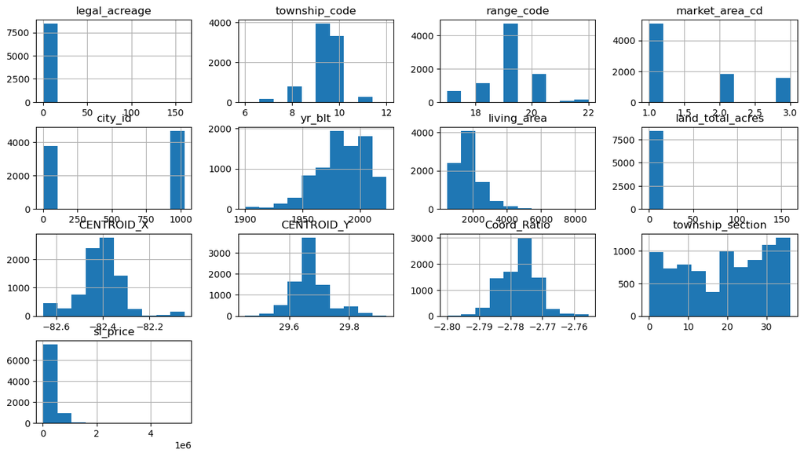

```python
train_data.hist(figsize =(15,8))
```

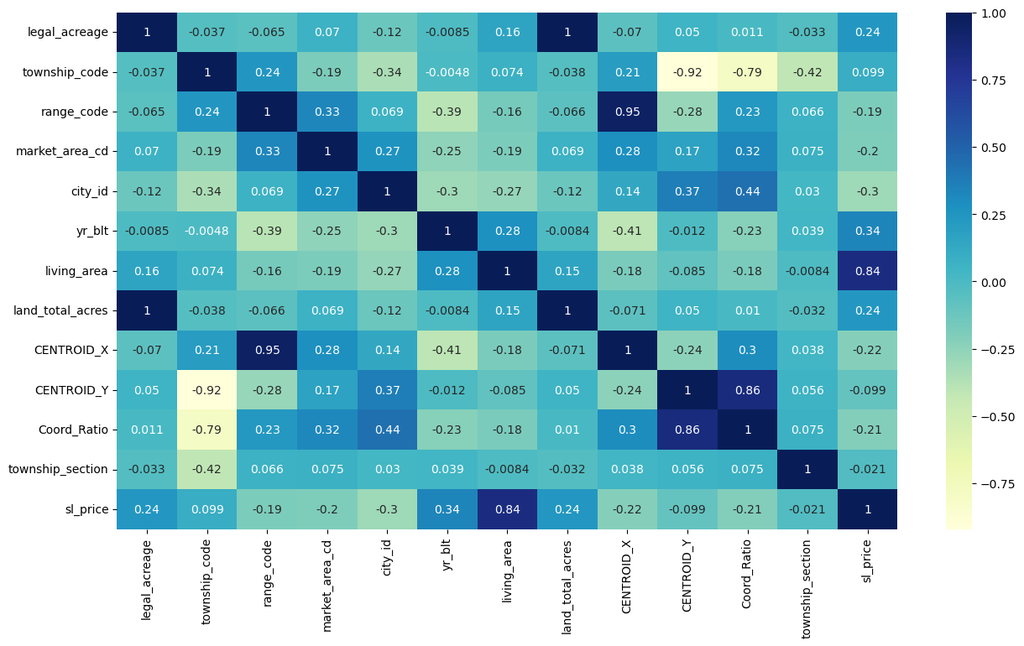

```python
plt.figure(figsize=(15,8))
sns.heatmap(train_data.corr(numeric_only=True), annot=True, cmap="YlGnBu")
```

```python
train_data['legal_acreage'] = np.log(train_data['legal_acreage'] + 1)
train_data['sl_price'] = np.log(train_data['sl_price'] + 1)
train_data['living_area'] = np.log(train_data['living_area'] + 1)
```

```
array([[<Axes: title={'center': 'legal_acreage'}>,
        <Axes: title={'center': 'township_code'}>,
        <Axes: title={'center': 'range_code'}>,
        <Axes: title={'center': 'market_area_cd'}>],
       [<Axes: title={'center': 'city_id'}>,
        <Axes: title={'center': 'yr_blt'}>,
        <Axes: title={'center': 'living_area'}>,
        <Axes: title={'center': 'land_total_acres'}>],
       [<Axes: title={'center': 'CENTROID_X'}>,
        <Axes: title={'center': 'CENTROID_Y'}>,
        <Axes: title={'center': 'Coord_Ratio'}>,
        <Axes: title={'center': 'township_section'}>],
       [<Axes: title={'center': 'sl_price'}>, <Axes: >, <Axes: >,
        <Axes: >]], dtype=object)
```

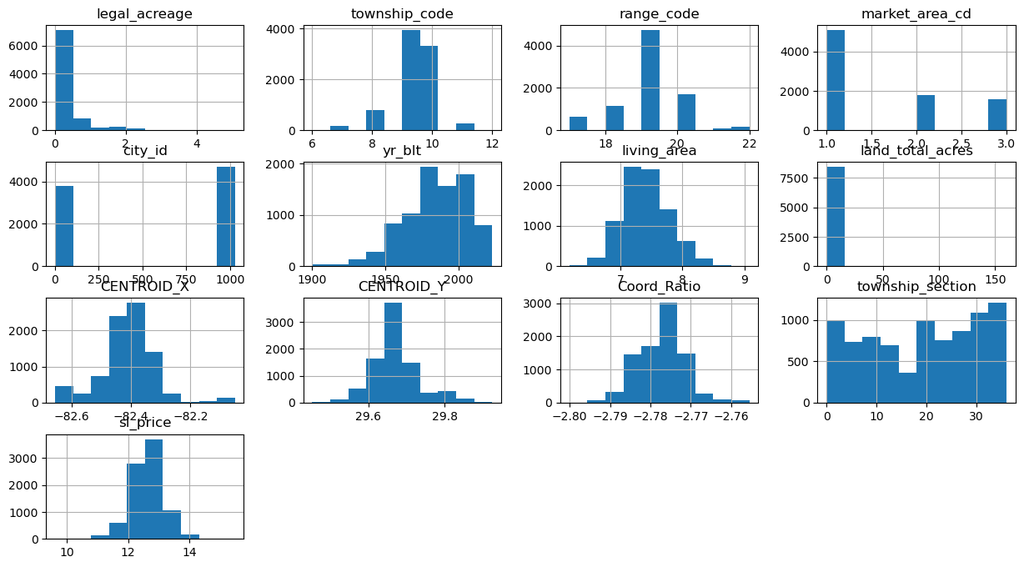

```python
train_data.hist(figsize=(15,8))
```

Need a location factor. Edit the MA spreadsheets to make Cluster ID unique then join into data

```python
market_area_1 = pd.read_csv('MA1_Export_20240719.csv')
market_area_2 = pd.read_csv('MA2_Export_20240719.csv')
market_area_3 = pd.read_csv('MA3_Export_20240719.csv')
data_2 = pd.read_csv("datapull1.csv")
```

```python
market_area_1 = market_area_1[['prop_id', 'Cluster_ID']]
market_area_2 = market_area_2[['prop_id', 'Cluster_ID']]
market_area_3 = market_area_3[['prop_id', 'Cluster_ID']]
```

[output not shown]

```python
market_area_1 = pd.read_csv('MA1_Export_20240719.csv')
market_area_2 = pd.read_csv('MA2_Export_20240719.csv')
market_area_3 = pd.read_csv('MA3_Export_20240719.csv')
data_2 = pd.read_csv("datapull1.csv")
```

```python
market_area_1 = market_area_1[['prop_id', 'Cluster_ID']]
market_area_2 = market_area_2[['prop_id', 'Cluster_ID']]
market_area_3 = market_area_3[['prop_id', 'Cluster_ID']]
```

```python
result_1 = pd.merge(data_2, market_area_1, how='left', on='prop_id')
result_2 = pd.merge(data_2, market_area_2, how='left', on='prop_id')
result_3 = pd.merge(data_2, market_area_3, how='left', on='prop_id')
```

[output not shown]

```python
data_2
```

|  | legal_acreage | hood_cd | township_code | range_code | market_area_cd | city_id | yr_blt | living_area | land_type_cd | condition_cd | land_total_acres | sl_price | CENTROID_X | CENTROID_Y | Coord_Ratio | township_section | Section_Township_Range | Range_Township_Section |
| --- | --- | --- | --- | --- | --- | --- | --- | --- | --- | --- | --- | --- | --- | --- | --- | --- | --- | --- |
| 0 | 7.98 | 222100 | 7.0 | 17.0 | 2.0 | 0.0 | 1998.0 | 2496.0 | AC | 4 | 7.98 | 961100.0 | -82.570565 | 29.848695 | -2.766304 | 25.0 | 25-07-17 | 17-07-25 |
| 1 | 3.89 | 222100.02 | 7.0 | 17.0 | 2.0 | 1019.0 | 2005.0 | 2468.0 | AC | 4 | 3.89 | 481700.0 | -82.611987 | 29.846721 | -2.767875 | 27.0 | 27-07-17 | 17-07-27 |
| 2 | 3.50 | 222100.02 | 7.0 | 17.0 | 2.0 | 1019.0 | 2006.0 | 2297.0 | AC | 4 | 3.50 | 573800.0 | -82.611772 | 29.842352 | -2.768273 | 27.0 | 27-07-17 | 17-07-27 |
| 3 | 1.20 | 222100.02 | 7.0 | 17.0 | 2.0 | 1019.0 | 2006.0 | 2414.0 | AC | 4 | 1.20 | 495000.0 | -82.609765 | 29.843912 | -2.768061 | 27.0 | 27-07-17 | 17-07-27 |
| 4 | 1.31 | 222100.24 | 7.0 | 17.0 | 2.0 | 0.0 | 1961.0 | 2016.0 | FF | 3 | 1.31 | 450000.0 | -82.632453 | 29.840165 | -2.769169 | 32.0 | 32-07-17 | 17-07-32 |
| ... | ... | ... | ... | ... | ... | ... | ... | ... | ... | ... | ... | ... | ... | ... | ... | ... | ... | ... |
| 13686 | NaN | NaN | NaN | NaN | NaN | NaN | NaN | NaN | NaN | NaN | NaN | NaN | NaN | NaN | NaN | NaN | NaN | NaN |
| 13687 | NaN | NaN | NaN | NaN | NaN | NaN | NaN | NaN | NaN | NaN | NaN | NaN | NaN | NaN | NaN | NaN | NaN | NaN |
| 13688 | NaN | NaN | NaN | NaN | NaN | NaN | NaN | NaN | NaN | NaN | NaN | NaN | NaN | NaN | NaN | NaN | NaN | NaN |
| 13689 | NaN | NaN | NaN | NaN | NaN | NaN | NaN | NaN | NaN | NaN | NaN | NaN | NaN | NaN | NaN | NaN | NaN | NaN |
| 13690 | NaN | NaN | NaN | NaN | NaN | NaN | NaN | NaN | NaN | NaN | NaN | NaN | NaN | NaN | NaN | NaN | NaN | NaN |

13691 rows × 18 columns

```python
data_2 = pd.read_csv("datapull1.csv")
```

```python
data_2
```

|  | legal_acreage | hood_cd | township_code | range_code | market_area_cd | city_id | yr_blt | living_area | land_type_cd | condition_cd | land_total_acres | sl_price | CENTROID_X | CENTROID_Y | Coord_Ratio | township_section | Section_Township_Range | Range_Township_Section |
| --- | --- | --- | --- | --- | --- | --- | --- | --- | --- | --- | --- | --- | --- | --- | --- | --- | --- | --- |
| 0 | 7.98 | 222100 | 7.0 | 17.0 | 2.0 | 0.0 | 1998.0 | 2496.0 | AC | 4 | 7.98 | 961100.0 | -82.570565 | 29.848695 | -2.766304 | 25.0 | 25-07-17 | 17-07-25 |
| 1 | 3.89 | 222100.02 | 7.0 | 17.0 | 2.0 | 1019.0 | 2005.0 | 2468.0 | AC | 4 | 3.89 | 481700.0 | -82.611987 | 29.846721 | -2.767875 | 27.0 | 27-07-17 | 17-07-27 |
| 2 | 3.50 | 222100.02 | 7.0 | 17.0 | 2.0 | 1019.0 | 2006.0 | 2297.0 | AC | 4 | 3.50 | 573800.0 | -82.611772 | 29.842352 | -2.768273 | 27.0 | 27-07-17 | 17-07-27 |
| 3 | 1.20 | 222100.02 | 7.0 | 17.0 | 2.0 | 1019.0 | 2006.0 | 2414.0 | AC | 4 | 1.20 | 495000.0 | -82.609765 | 29.843912 | -2.768061 | 27.0 | 27-07-17 | 17-07-27 |
| 4 | 1.31 | 222100.24 | 7.0 | 17.0 | 2.0 | 0.0 | 1961.0 | 2016.0 | FF | 3 | 1.31 | 450000.0 | -82.632453 | 29.840165 | -2.769169 | 32.0 | 32-07-17 | 17-07-32 |
| ... | ... | ... | ... | ... | ... | ... | ... | ... | ... | ... | ... | ... | ... | ... | ... | ... | ... | ... |
| 13686 | NaN | NaN | NaN | NaN | NaN | NaN | NaN | NaN | NaN | NaN | NaN | NaN | NaN | NaN | NaN | NaN | NaN | NaN |
| 13687 | NaN | NaN | NaN | NaN | NaN | NaN | NaN | NaN | NaN | NaN | NaN | NaN | NaN | NaN | NaN | NaN | NaN | NaN |
| 13688 | NaN | NaN | NaN | NaN | NaN | NaN | NaN | NaN | NaN | NaN | NaN | NaN | NaN | NaN | NaN | NaN | NaN | NaN |
| 13689 | NaN | NaN | NaN | NaN | NaN | NaN | NaN | NaN | NaN | NaN | NaN | NaN | NaN | NaN | NaN | NaN | NaN | NaN |
| 13690 | NaN | NaN | NaN | NaN | NaN | NaN | NaN | NaN | NaN | NaN | NaN | NaN | NaN | NaN | NaN | NaN | NaN | NaN |

13691 rows × 18 columns

```python
data_2
```

|  | legal_acreage | hood_cd | township_code | range_code | market_area_cd | city_id | yr_blt | living_area | land_type_cd | condition_cd | land_total_acres | sl_price | CENTROID_X | CENTROID_Y | Coord_Ratio | township_section | Section_Township_Range | Range_Township_Section |
| --- | --- | --- | --- | --- | --- | --- | --- | --- | --- | --- | --- | --- | --- | --- | --- | --- | --- | --- |
| 0 | 7.98 | 222100 | 7.0 | 17.0 | 2.0 | 0.0 | 1998.0 | 2496.0 | AC | 4 | 7.98 | 961100.0 | -82.570565 | 29.848695 | -2.766304 | 25.0 | 25-07-17 | 17-07-25 |
| 1 | 3.89 | 222100.02 | 7.0 | 17.0 | 2.0 | 1019.0 | 2005.0 | 2468.0 | AC | 4 | 3.89 | 481700.0 | -82.611987 | 29.846721 | -2.767875 | 27.0 | 27-07-17 | 17-07-27 |
| 2 | 3.50 | 222100.02 | 7.0 | 17.0 | 2.0 | 1019.0 | 2006.0 | 2297.0 | AC | 4 | 3.50 | 573800.0 | -82.611772 | 29.842352 | -2.768273 | 27.0 | 27-07-17 | 17-07-27 |
| 3 | 1.20 | 222100.02 | 7.0 | 17.0 | 2.0 | 1019.0 | 2006.0 | 2414.0 | AC | 4 | 1.20 | 495000.0 | -82.609765 | 29.843912 | -2.768061 | 27.0 | 27-07-17 | 17-07-27 |
| 4 | 1.31 | 222100.24 | 7.0 | 17.0 | 2.0 | 0.0 | 1961.0 | 2016.0 | FF | 3 | 1.31 | 450000.0 | -82.632453 | 29.840165 | -2.769169 | 32.0 | 32-07-17 | 17-07-32 |
| ... | ... | ... | ... | ... | ... | ... | ... | ... | ... | ... | ... | ... | ... | ... | ... | ... | ... | ... |
| 13686 | NaN | NaN | NaN | NaN | NaN | NaN | NaN | NaN | NaN | NaN | NaN | NaN | NaN | NaN | NaN | NaN | NaN | NaN |
| 13687 | NaN | NaN | NaN | NaN | NaN | NaN | NaN | NaN | NaN | NaN | NaN | NaN | NaN | NaN | NaN | NaN | NaN | NaN |
| 13688 | NaN | NaN | NaN | NaN | NaN | NaN | NaN | NaN | NaN | NaN | NaN | NaN | NaN | NaN | NaN | NaN | NaN | NaN |
| 13689 | NaN | NaN | NaN | NaN | NaN | NaN | NaN | NaN | NaN | NaN | NaN | NaN | NaN | NaN | NaN | NaN | NaN | NaN |
| 13690 | NaN | NaN | NaN | NaN | NaN | NaN | NaN | NaN | NaN | NaN | NaN | NaN | NaN | NaN | NaN | NaN | NaN | NaN |

13691 rows × 18 columns

```python
data_2 = pd.read_csv("datapull1.csv")
```

```python
data_2
```

|  | prop_id | legal_acreage | city_id | yr_blt | living_area | land_type_cd | condition_cd | land_total_acres | sl_price | Unnamed: 9 | Unnamed: 10 | Unnamed: 11 | Unnamed: 12 | Unnamed: 13 | Unnamed: 14 | Unnamed: 15 | Unnamed: 16 |
| --- | --- | --- | --- | --- | --- | --- | --- | --- | --- | --- | --- | --- | --- | --- | --- | --- | --- |
| 0 | 1058 | 7.93 | 0 | 2000 | 2412 | AC | 3 | 7.9300 | 492600 | NaN | NaN | NaN | NaN | NaN | NaN | NaN | NaN |
| 1 | 1270 | 2.57 | 0 | 2005 | 2809 | LT | 4 | 2.5700 | 625300 | NaN | NaN | NaN | NaN | NaN | NaN | NaN | NaN |
| 2 | 1307 | 2 | 0 | 2005 | 2508 | AC | 4 | 2.0000 | 535500 | NaN | NaN | NaN | NaN | NaN | NaN | NaN | NaN |
| 3 | 1358 | 1.29 | 1019 | 2005 | 2587 | AC | 4 | 1.2900 | 544500 | NaN | NaN | NaN | NaN | NaN | NaN | NaN | NaN |
| 4 | 1416 | 1.07 | 1019 | 1973 | 2260 | AC | 3 | 1.0700 | 199700 | NaN | NaN | NaN | NaN | NaN | NaN | NaN | NaN |
| ... | ... | ... | ... | ... | ... | ... | ... | ... | ... | ... | ... | ... | ... | ... | ... | ... | ... |
| 11175 | 504115 | 0.1446 | 1016 | 2023 | 1816 | LT | 3 | 0.1446 | 418400 | NaN | NaN | NaN | NaN | NaN | NaN | NaN | NaN |
| 11176 | 504141 | 0.1461 | 1016 | 2022 | 1810 | LT | NaN | 0.1461 | 416300 | NaN | NaN | NaN | NaN | NaN | NaN | NaN | NaN |
| 11177 | 504347 | 0.14 | 1022 | 2022 | 1779 | LT | 3 | 0.1400 | 346500 | NaN | NaN | NaN | NaN | NaN | NaN | NaN | NaN |
| 11178 | 504410 | 0.1422 | 1019 | 2022 | 2535 | LT | NaN | 0.1422 | 372700 | NaN | NaN | NaN | NaN | NaN | NaN | NaN | NaN |
| 11179 | 504928 | 1.9 | 0 | 1977 | 1534 | AC | 3 | 1.9000 | 408800 | NaN | NaN | NaN | NaN | NaN | NaN | NaN | NaN |

11180 rows × 17 columns

```python
market_area_1 = market_area_1[['prop_id', 'Cluster_ID']]
market_area_2 = market_area_2[['prop_id', 'Cluster_ID']]
market_area_3 = market_area_3[['prop_id', 'Cluster_ID']]
```

```python
result_1 = pd.merge(data_2, market_area_1, how='left', on='prop_id')
result_2 = pd.merge(data_2, market_area_2, how='left', on='prop_id')
result_3 = pd.merge(data_2, market_area_3, how='left', on='prop_id')
```

```python
data_2
```

|  | prop_id | legal_acreage | city_id | yr_blt | living_area | land_type_cd | condition_cd | land_total_acres | sl_price | Unnamed: 9 | Unnamed: 10 | Unnamed: 11 | Unnamed: 12 | Unnamed: 13 | Unnamed: 14 | Unnamed: 15 | Unnamed: 16 |
| --- | --- | --- | --- | --- | --- | --- | --- | --- | --- | --- | --- | --- | --- | --- | --- | --- | --- |
| 0 | 1058 | 7.93 | 0 | 2000 | 2412 | AC | 3 | 7.9300 | 492600 | NaN | NaN | NaN | NaN | NaN | NaN | NaN | NaN |
| 1 | 1270 | 2.57 | 0 | 2005 | 2809 | LT | 4 | 2.5700 | 625300 | NaN | NaN | NaN | NaN | NaN | NaN | NaN | NaN |
| 2 | 1307 | 2 | 0 | 2005 | 2508 | AC | 4 | 2.0000 | 535500 | NaN | NaN | NaN | NaN | NaN | NaN | NaN | NaN |
| 3 | 1358 | 1.29 | 1019 | 2005 | 2587 | AC | 4 | 1.2900 | 544500 | NaN | NaN | NaN | NaN | NaN | NaN | NaN | NaN |
| 4 | 1416 | 1.07 | 1019 | 1973 | 2260 | AC | 3 | 1.0700 | 199700 | NaN | NaN | NaN | NaN | NaN | NaN | NaN | NaN |
| ... | ... | ... | ... | ... | ... | ... | ... | ... | ... | ... | ... | ... | ... | ... | ... | ... | ... |
| 11175 | 504115 | 0.1446 | 1016 | 2023 | 1816 | LT | 3 | 0.1446 | 418400 | NaN | NaN | NaN | NaN | NaN | NaN | NaN | NaN |
| 11176 | 504141 | 0.1461 | 1016 | 2022 | 1810 | LT | NaN | 0.1461 | 416300 | NaN | NaN | NaN | NaN | NaN | NaN | NaN | NaN |
| 11177 | 504347 | 0.14 | 1022 | 2022 | 1779 | LT | 3 | 0.1400 | 346500 | NaN | NaN | NaN | NaN | NaN | NaN | NaN | NaN |
| 11178 | 504410 | 0.1422 | 1019 | 2022 | 2535 | LT | NaN | 0.1422 | 372700 | NaN | NaN | NaN | NaN | NaN | NaN | NaN | NaN |
| 11179 | 504928 | 1.9 | 0 | 1977 | 1534 | AC | 3 | 1.9000 | 408800 | NaN | NaN | NaN | NaN | NaN | NaN | NaN | NaN |

11180 rows × 17 columns

```python
market_area_1 = pd.read_csv('MA1_Export_20240719.csv')
market_area_2 = pd.read_csv('MA2_Export_20240719.csv')
market_area_3 = pd.read_csv('MA3_Export_20240719.csv')
data_2 = pd.read_csv("datapull1.csv")
```

```python
market_area_1 = market_area_1[['prop_id', 'Cluster_ID']]
market_area_2 = market_area_2[['prop_id', 'Cluster_ID']]
market_area_3 = market_area_3[['prop_id', 'Cluster_ID']]
```

```python
result_1 = pd.merge(data_2, market_area_1, how='left', on='prop_id')
result_2 = pd.merge(data_2, market_area_2, how='left', on='prop_id')
result_3 = pd.merge(data_2, market_area_3, how='left', on='prop_id')
```

```python
data_2
```

|  | prop_id | legal_acreage | city_id | yr_blt | living_area | land_type_cd | condition_cd | land_total_acres | sl_price | Unnamed: 9 | Unnamed: 10 | Unnamed: 11 | Unnamed: 12 | Unnamed: 13 | Unnamed: 14 | Unnamed: 15 | Unnamed: 16 |
| --- | --- | --- | --- | --- | --- | --- | --- | --- | --- | --- | --- | --- | --- | --- | --- | --- | --- |
| 0 | 1058 | 7.93 | 0 | 2000 | 2412 | AC | 3 | 7.9300 | 492600 | NaN | NaN | NaN | NaN | NaN | NaN | NaN | NaN |
| 1 | 1270 | 2.57 | 0 | 2005 | 2809 | LT | 4 | 2.5700 | 625300 | NaN | NaN | NaN | NaN | NaN | NaN | NaN | NaN |
| 2 | 1307 | 2 | 0 | 2005 | 2508 | AC | 4 | 2.0000 | 535500 | NaN | NaN | NaN | NaN | NaN | NaN | NaN | NaN |
| 3 | 1358 | 1.29 | 1019 | 2005 | 2587 | AC | 4 | 1.2900 | 544500 | NaN | NaN | NaN | NaN | NaN | NaN | NaN | NaN |
| 4 | 1416 | 1.07 | 1019 | 1973 | 2260 | AC | 3 | 1.0700 | 199700 | NaN | NaN | NaN | NaN | NaN | NaN | NaN | NaN |
| ... | ... | ... | ... | ... | ... | ... | ... | ... | ... | ... | ... | ... | ... | ... | ... | ... | ... |
| 11175 | 504115 | 0.1446 | 1016 | 2023 | 1816 | LT | 3 | 0.1446 | 418400 | NaN | NaN | NaN | NaN | NaN | NaN | NaN | NaN |
| 11176 | 504141 | 0.1461 | 1016 | 2022 | 1810 | LT | NaN | 0.1461 | 416300 | NaN | NaN | NaN | NaN | NaN | NaN | NaN | NaN |
| 11177 | 504347 | 0.14 | 1022 | 2022 | 1779 | LT | 3 | 0.1400 | 346500 | NaN | NaN | NaN | NaN | NaN | NaN | NaN | NaN |
| 11178 | 504410 | 0.1422 | 1019 | 2022 | 2535 | LT | NaN | 0.1422 | 372700 | NaN | NaN | NaN | NaN | NaN | NaN | NaN | NaN |
| 11179 | 504928 | 1.9 | 0 | 1977 | 1534 | AC | 3 | 1.9000 | 408800 | NaN | NaN | NaN | NaN | NaN | NaN | NaN | NaN |

11180 rows × 17 columns

```python
market_area_1 = pd.read_csv('MA1_Export_20240719.csv')
market_area_2 = pd.read_csv('MA2_Export_20240719.csv')
market_area_3 = pd.read_csv('MA3_Export_20240719.csv')
data_2 = pd.read_csv("datapull1.csv")
```

```python
market_area_1 = market_area_1[['prop_id', 'Cluster_ID']]
market_area_2 = market_area_2[['prop_id', 'Cluster_ID']]
market_area_3 = market_area_3[['prop_id', 'Cluster_ID']]
```

```python
market_area_1 = market_area_1[['prop_id', 'Cluster_ID']]
market_area_2 = market_area_2[['prop_id', 'Cluster_ID']]
market_area_3 = market_area_3[['prop_id', 'Cluster_ID']]
```

```python
market_areas = pd.concat([market_area_1, market_area_2, market_area_3])
result = pd.merge(data_2, market_areas, how='left', on='prop_id')
```

```python
market_areas = pd.concat([market_area_1, market_area_2, market_area_3])
result = pd.merge(data_2, market_areas, how='left', on='prop_id')
```

```python
print(result.columns)
print(result.dtypes)
```

```
Index(['prop_id', 'legal_acreage', 'city_id', 'yr_blt', 'living_area',
       'land_type_cd', 'condition_cd', 'land_total_acres', 'sl_price',
       'Unnamed: 9', 'Unnamed: 10', 'Unnamed: 11', 'Unnamed: 12',
       'Unnamed: 13', 'Unnamed: 14', 'Unnamed: 15', 'Unnamed: 16',
       'Cluster_ID'],
      dtype='object')
prop_id               int64
legal_acreage        object
city_id               int64
yr_blt                int64
living_area           int64
land_type_cd         object
condition_cd         object
land_total_acres    float64
sl_price              int64
Unnamed: 9          float64
Unnamed: 10         float64
Unnamed: 11         float64
Unnamed: 12         float64
Unnamed: 13         float64
Unnamed: 14         float64
Unnamed: 15         float64
Unnamed: 16         float64
Cluster_ID           object
dtype: object
```

```python
print(data_2.columns)
print(market_area_1.columns)
print(market_area_2.columns)
print(market_area_3.columns)
```

```
Index(['prop_id', 'legal_acreage', 'city_id', 'yr_blt', 'living_area',
       'land_type_cd', 'condition_cd', 'land_total_acres', 'sl_price',
       'Unnamed: 9', 'Unnamed: 10', 'Unnamed: 11', 'Unnamed: 12',
       'Unnamed: 13', 'Unnamed: 14', 'Unnamed: 15', 'Unnamed: 16'],
      dtype='object')
Index(['prop_id', 'Cluster_ID'], dtype='object')
Index(['prop_id', 'Cluster_ID'], dtype='object')
Index(['prop_id', 'Cluster_ID'], dtype='object')
```

```python
market_area_1 = pd.read_csv('MA1_Export_20240719.csv')
market_area_2 = pd.read_csv('MA2_Export_20240719.csv')
market_area_3 = pd.read_csv('MA3_Export_20240719.csv')
data_2 = pd.read_csv("datapull1.csv")
```

```python
print(data_2.columns)
print(market_area_1.columns)
print(market_area_2.columns)
print(market_area_3.columns)
```

```
Index(['prop_id', 'legal_acreage', 'city_id', 'yr_blt', 'living_area',
       'land_type_cd', 'condition_cd', 'land_total_acres', 'sl_price',
       'Unnamed: 9', 'Unnamed: 10', 'Unnamed: 11', 'Unnamed: 12',
       'Unnamed: 13', 'Unnamed: 14', 'Unnamed: 15', 'Unnamed: 16'],
      dtype='object')
Index(['OBJECTID', 'Join_Count', 'TARGET_FID', 'Field1', 'prop_id',
       'centroid_x', 'centroid_y', 'quality', 'actage', 'lotsize', 'effage',
       'market_area_cd', 'FSP_area', 'FGR_area', 'FSP', 'FGR', 'Total_Area',
       'livarea', 'SOURCE_ID', 'quality.1', 'actage.1', 'lotsize.1', 'FGR.1',
       'livarea.1', 'Cluster_ID', 'Membership Probability'],
      dtype='object')
Index(['OBJECTID', 'Join_Count', 'TARGET_FID', 'Field1', 'prop_id',
       'centroid_x', 'centroid_y', 'quality', 'actage', 'lotsize', 'effage',
       'market_area_cd', 'FSP_area', 'FGR_area', 'FSP', 'FGR', 'Total_Area',
       'livarea', 'SOURCE_ID', 'quality.1', 'actage.1', 'lotsize.1', 'FGR.1',
       'livarea.1', 'Cluster_ID', 'Membership Probability'],
      dtype='object')
Index(['OBJECTID', 'Join_Count', 'TARGET_FID', 'Field1', 'prop_id',
       'centroid_x', 'centroid_y', 'quality', 'actage', 'lotsize', 'effage',
       'market_area_cd', 'FSP_area', 'FGR_area', 'FSP', 'FGR', 'Total_Area',
       'livarea', 'SOURCE_ID', 'Cluster_ID', 'Membership Probability'],
      dtype='object')
```

```python
market_area_1 = market_area_1[['prop_id', 'Cluster_ID']]
market_area_2 = market_area_2[['prop_id', 'Cluster_ID']]
market_area_3 = market_area_3[['prop_id', 'Cluster_ID']]
```

```python
print(data_2.columns)
print(market_area_1.columns)
print(market_area_2.columns)
print(market_area_3.columns)
```

```
Index(['prop_id', 'legal_acreage', 'city_id', 'yr_blt', 'living_area',
       'land_type_cd', 'condition_cd', 'land_total_acres', 'sl_price',
       'Unnamed: 9', 'Unnamed: 10', 'Unnamed: 11', 'Unnamed: 12',
       'Unnamed: 13', 'Unnamed: 14', 'Unnamed: 15', 'Unnamed: 16'],
      dtype='object')
Index(['prop_id', 'Cluster_ID'], dtype='object')
Index(['prop_id', 'Cluster_ID'], dtype='object')
Index(['prop_id', 'Cluster_ID'], dtype='object')
```

```python
market_area_1 = pd.read_csv('MA1_Export_20240719.csv')
market_area_2 = pd.read_csv('MA2_Export_20240719.csv')
market_area_3 = pd.read_csv('MA3_Export_20240719.csv')
data_2 = pd.read_csv("datapull1.csv")
```

```python
print(data_2.columns)
print(market_area_1.columns)
print(market_area_2.columns)
print(market_area_3.columns)
```

```
Index(['prop_id', 'legal_acreage', 'city_id', 'yr_blt', 'living_area',
       'land_type_cd', 'condition_cd', 'land_total_acres', 'sl_price',
       'Unnamed: 9', 'Unnamed: 10', 'Unnamed: 11', 'Unnamed: 12',
       'Unnamed: 13', 'Unnamed: 14', 'Unnamed: 15', 'Unnamed: 16'],
      dtype='object')
Index(['OBJECTID', 'Join_Count', 'TARGET_FID', 'Field1', 'prop_id',
       'centroid_x', 'centroid_y', 'quality', 'actage', 'lotsize', 'effage',
       'market_area_cd', 'FSP_area', 'FGR_area', 'FSP', 'FGR', 'Total_Area',
       'livarea', 'SOURCE_ID', 'quality.1', 'actage.1', 'lotsize.1', 'FGR.1',
       'livarea.1', 'Cluster_ID', 'Membership Probability'],
      dtype='object')
Index(['OBJECTID', 'Join_Count', 'TARGET_FID', 'Field1', 'prop_id',
       'centroid_x', 'centroid_y', 'quality', 'actage', 'lotsize', 'effage',
       'market_area_cd', 'FSP_area', 'FGR_area', 'FSP', 'FGR', 'Total_Area',
       'livarea', 'SOURCE_ID', 'quality.1', 'actage.1', 'lotsize.1', 'FGR.1',
       'livarea.1', 'Cluster_ID', 'Membership Probability'],
      dtype='object')
Index(['OBJECTID', 'Join_Count', 'TARGET_FID', 'Field1', 'prop_id',
       'centroid_x', 'centroid_y', 'quality', 'actage', 'lotsize', 'effage',
       'market_area_cd', 'FSP_area', 'FGR_area', 'FSP', 'FGR', 'Total_Area',
       'livarea', 'SOURCE_ID', 'Cluster_ID', 'Membership Probability'],
      dtype='object')
```

```python
market_area_1 = pd.read_csv('MA1_Export_20240719.csv')
market_area_2 = pd.read_csv('MA2_Export_20240719.csv')
market_area_3 = pd.read_csv('MA3_Export_20240719.csv')
data_2 = pd.read_csv("datapull2.csv")
```

```python
print(data_2.columns)
print(market_area_1.columns)
print(market_area_2.columns)
print(market_area_3.columns)
```

```
Index(['prop_id', 'legal_acreage', 'city_id', 'yr_blt', 'living_area',
       'land_type_cd', 'condition_cd', 'land_total_acres', 'sl_price'],
      dtype='object')
Index(['OBJECTID', 'Join_Count', 'TARGET_FID', 'Field1', 'prop_id',
       'centroid_x', 'centroid_y', 'quality', 'actage', 'lotsize', 'effage',
       'market_area_cd', 'FSP_area', 'FGR_area', 'FSP', 'FGR', 'Total_Area',
       'livarea', 'SOURCE_ID', 'quality.1', 'actage.1', 'lotsize.1', 'FGR.1',
       'livarea.1', 'Cluster_ID', 'Membership Probability'],
      dtype='object')
Index(['OBJECTID', 'Join_Count', 'TARGET_FID', 'Field1', 'prop_id',
       'centroid_x', 'centroid_y', 'quality', 'actage', 'lotsize', 'effage',
       'market_area_cd', 'FSP_area', 'FGR_area', 'FSP', 'FGR', 'Total_Area',
       'livarea', 'SOURCE_ID', 'quality.1', 'actage.1', 'lotsize.1', 'FGR.1',
       'livarea.1', 'Cluster_ID', 'Membership Probability'],
      dtype='object')
Index(['OBJECTID', 'Join_Count', 'TARGET_FID', 'Field1', 'prop_id',
       'centroid_x', 'centroid_y', 'quality', 'actage', 'lotsize', 'effage',
       'market_area_cd', 'FSP_area', 'FGR_area', 'FSP', 'FGR', 'Total_Area',
       'livarea', 'SOURCE_ID', 'Cluster_ID', 'Membership Probability'],
      dtype='object')
```

```python
market_area_1 = market_area_1[['prop_id', 'Cluster_ID']]
market_area_2 = market_area_2[['prop_id', 'Cluster_ID']]
market_area_3 = market_area_3[['prop_id', 'Cluster_ID']]
```

```python
market_areas = pd.concat([market_area_1, market_area_2, market_area_3])
result = pd.merge(data_2, market_areas, how='left', on='prop_id')
```

```python
print(result.columns)
print(result.dtypes)
```

```
Index(['prop_id', 'legal_acreage', 'city_id', 'yr_blt', 'living_area',
       'land_type_cd', 'condition_cd', 'land_total_acres', 'sl_price',
       'Cluster_ID'],
      dtype='object')
prop_id               int64
legal_acreage       float64
city_id               int64
yr_blt                int64
living_area           int64
land_type_cd         object
condition_cd         object
land_total_acres    float64
sl_price              int64
Cluster_ID           object
dtype: object
```

```python
print(result.columns)
print(result.dtypes)
```

```
Index(['prop_id', 'legal_acreage', 'city_id', 'yr_blt', 'living_area',
       'land_type_cd', 'condition_cd', 'land_total_acres', 'sl_price',
       'Cluster_ID'],
      dtype='object')
prop_id               int64
legal_acreage       float64
city_id               int64
yr_blt                int64
living_area           int64
land_type_cd         object
condition_cd         object
land_total_acres    float64
sl_price              int64
Cluster_ID           object
dtype: object
```

```python
result
```

|  | prop_id | legal_acreage | city_id | yr_blt | living_area | land_type_cd | condition_cd | land_total_acres | sl_price | Cluster_ID |
| --- | --- | --- | --- | --- | --- | --- | --- | --- | --- | --- |
| 0 | 1058 | 7.9300 | 0 | 2000 | 2412 | AC | 3 | 7.9300 | 492600 | B1 |
| 1 | 1270 | 2.5700 | 0 | 2005 | 2809 | LT | 4 | 2.5700 | 625300 | B1 |
| 2 | 1307 | 2.0000 | 0 | 2005 | 2508 | AC | 4 | 2.0000 | 535500 | B1 |
| 3 | 1358 | 1.2900 | 1019 | 2005 | 2587 | AC | 4 | 1.2900 | 544500 | B1 |
| 4 | 1416 | 1.0700 | 1019 | 1973 | 2260 | AC | 3 | 1.0700 | 199700 | B1 |
| ... | ... | ... | ... | ... | ... | ... | ... | ... | ... | ... |
| 11175 | 504115 | 0.1446 | 1016 | 2023 | 1816 | LT | 3 | 0.1446 | 418400 | NaN |
| 11176 | 504141 | 0.1461 | 1016 | 2022 | 1810 | LT | NaN | 0.1461 | 416300 | NaN |
| 11177 | 504347 | 0.1400 | 1022 | 2022 | 1779 | LT | 3 | 0.1400 | 346500 | NaN |
| 11178 | 504410 | 0.1422 | 1019 | 2022 | 2535 | LT | NaN | 0.1422 | 372700 | NaN |
| 11179 | 504928 | 1.9000 | 0 | 1977 | 1534 | AC | 3 | 1.9000 | 408800 | B2 |

11180 rows × 10 columns

Redo the data transfromation but maybe let's do it before we split out the test data because Im tired of doing things twice and this doc is going to get messy and need to be pruned.

```python
result.dropna(inplace=True)
```

```python
result
```

|  | prop_id | legal_acreage | city_id | yr_blt | living_area | land_type_cd | condition_cd | land_total_acres | sl_price | Cluster_ID |
| --- | --- | --- | --- | --- | --- | --- | --- | --- | --- | --- |
| 0 | 1058 | 7.9300 | 0 | 2000 | 2412 | AC | 3 | 7.9300 | 492600 | B1 |
| 1 | 1270 | 2.5700 | 0 | 2005 | 2809 | LT | 4 | 2.5700 | 625300 | B1 |
| 2 | 1307 | 2.0000 | 0 | 2005 | 2508 | AC | 4 | 2.0000 | 535500 | B1 |
| 3 | 1358 | 1.2900 | 1019 | 2005 | 2587 | AC | 4 | 1.2900 | 544500 | B1 |
| 4 | 1416 | 1.0700 | 1019 | 1973 | 2260 | AC | 3 | 1.0700 | 199700 | B1 |
| ... | ... | ... | ... | ... | ... | ... | ... | ... | ... | ... |
| 11124 | 107614 | 0.2342 | 1022 | 2017 | 2028 | LT | 3 | 0.2342 | 402300 | B1 |
| 11126 | 108149 | 0.1983 | 0 | 2021 | 2814 | LT | 4 | 0.1983 | 657700 | B2 |
| 11161 | 502621 | 1.0700 | 0 | 1967 | 1344 | AC | 3 | 1.0700 | 235300 | A1 |
| 11164 | 503179 | 0.2300 | 1018 | 1930 | 1374 | UN | 2 | 0.2300 | 27200 | C4 |
| 11179 | 504928 | 1.9000 | 0 | 1977 | 1534 | AC | 3 | 1.9000 | 408800 | B2 |

10513 rows × 10 columns

```python
plt.figure(figsize=(15,8))
sns.heatmap(result.corr(numeric_only=True), annot=True, cmap="YlGnBu")
```

[output not shown]

```python
result.drop(['prop_id'], axis=1)
```

|  | legal_acreage | city_id | yr_blt | living_area | land_type_cd | condition_cd | land_total_acres | sl_price | Cluster_ID |
| --- | --- | --- | --- | --- | --- | --- | --- | --- | --- |
| 0 | 7.9300 | 0 | 2000 | 2412 | AC | 3 | 7.9300 | 492600 | B1 |
| 1 | 2.5700 | 0 | 2005 | 2809 | LT | 4 | 2.5700 | 625300 | B1 |
| 2 | 2.0000 | 0 | 2005 | 2508 | AC | 4 | 2.0000 | 535500 | B1 |
| 3 | 1.2900 | 1019 | 2005 | 2587 | AC | 4 | 1.2900 | 544500 | B1 |
| 4 | 1.0700 | 1019 | 1973 | 2260 | AC | 3 | 1.0700 | 199700 | B1 |
| ... | ... | ... | ... | ... | ... | ... | ... | ... | ... |
| 11124 | 0.2342 | 1022 | 2017 | 2028 | LT | 3 | 0.2342 | 402300 | B1 |
| 11126 | 0.1983 | 0 | 2021 | 2814 | LT | 4 | 0.1983 | 657700 | B2 |
| 11161 | 1.0700 | 0 | 1967 | 1344 | AC | 3 | 1.0700 | 235300 | A1 |
| 11164 | 0.2300 | 1018 | 1930 | 1374 | UN | 2 | 0.2300 | 27200 | C4 |
| 11179 | 1.9000 | 0 | 1977 | 1534 | AC | 3 | 1.9000 | 408800 | B2 |

10513 rows × 9 columns

```python
plt.figure(figsize=(15,8))
sns.heatmap(result.corr(numeric_only=True), annot=True, cmap="YlGnBu")
```

[output not shown]

```python
result.drop(['prop_id'], axis=1)
```

|  | legal_acreage | city_id | yr_blt | living_area | land_type_cd | condition_cd | land_total_acres | sl_price | Cluster_ID |
| --- | --- | --- | --- | --- | --- | --- | --- | --- | --- |
| 0 | 7.9300 | 0 | 2000 | 2412 | AC | 3 | 7.9300 | 492600 | B1 |
| 1 | 2.5700 | 0 | 2005 | 2809 | LT | 4 | 2.5700 | 625300 | B1 |
| 2 | 2.0000 | 0 | 2005 | 2508 | AC | 4 | 2.0000 | 535500 | B1 |
| 3 | 1.2900 | 1019 | 2005 | 2587 | AC | 4 | 1.2900 | 544500 | B1 |
| 4 | 1.0700 | 1019 | 1973 | 2260 | AC | 3 | 1.0700 | 199700 | B1 |
| ... | ... | ... | ... | ... | ... | ... | ... | ... | ... |
| 11124 | 0.2342 | 1022 | 2017 | 2028 | LT | 3 | 0.2342 | 402300 | B1 |
| 11126 | 0.1983 | 0 | 2021 | 2814 | LT | 4 | 0.1983 | 657700 | B2 |
| 11161 | 1.0700 | 0 | 1967 | 1344 | AC | 3 | 1.0700 | 235300 | A1 |
| 11164 | 0.2300 | 1018 | 1930 | 1374 | UN | 2 | 0.2300 | 27200 | C4 |
| 11179 | 1.9000 | 0 | 1977 | 1534 | AC | 3 | 1.9000 | 408800 | B2 |

10513 rows × 9 columns

```python
plt.figure(figsize=(15,8))
sns.heatmap(result.corr(numeric_only=True), annot=True, cmap="YlGnBu")
```

[output not shown]

```python
result = result.drop(['prop_id'], axis=1)
```

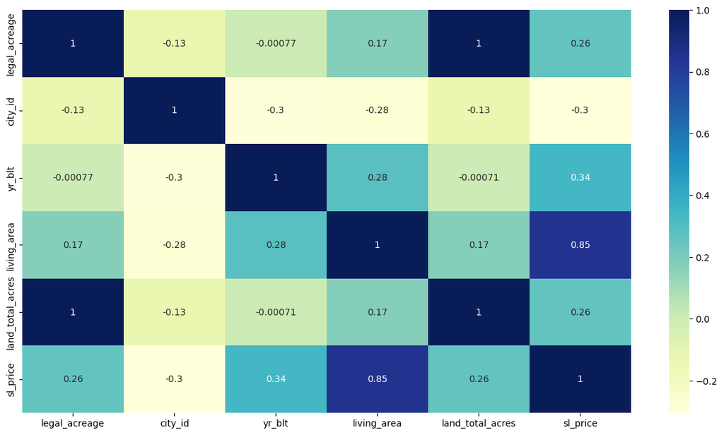

```python
plt.figure(figsize=(15,8))
sns.heatmap(result.corr(numeric_only=True), annot=True, cmap="YlGnBu")
```

```
array([[<Axes: title={'center': 'legal_acreage'}>,
        <Axes: title={'center': 'city_id'}>],
       [<Axes: title={'center': 'yr_blt'}>,
        <Axes: title={'center': 'living_area'}>],
       [<Axes: title={'center': 'land_total_acres'}>,
        <Axes: title={'center': 'sl_price'}>]], dtype=object)
```

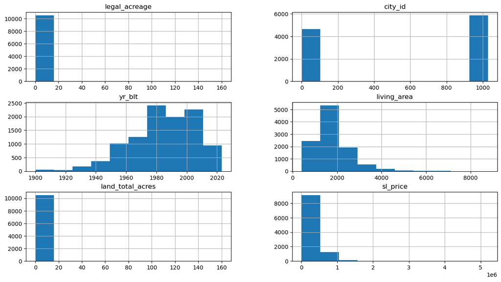

```python
result.hist(figsize =(15,8))
```

```python
result=result.drop(['land_total_acres'])
```

[output not shown]

```python
result=result.drop(['land_total_acres'], axis=1)
# %
```

```python
result
```

|  | legal_acreage | city_id | yr_blt | living_area | land_type_cd | condition_cd | sl_price | Cluster_ID |
| --- | --- | --- | --- | --- | --- | --- | --- | --- |
| 0 | 7.9300 | 0 | 2000 | 2412 | AC | 3 | 492600 | B1 |
| 1 | 2.5700 | 0 | 2005 | 2809 | LT | 4 | 625300 | B1 |
| 2 | 2.0000 | 0 | 2005 | 2508 | AC | 4 | 535500 | B1 |
| 3 | 1.2900 | 1019 | 2005 | 2587 | AC | 4 | 544500 | B1 |
| 4 | 1.0700 | 1019 | 1973 | 2260 | AC | 3 | 199700 | B1 |
| ... | ... | ... | ... | ... | ... | ... | ... | ... |
| 11124 | 0.2342 | 1022 | 2017 | 2028 | LT | 3 | 402300 | B1 |
| 11126 | 0.1983 | 0 | 2021 | 2814 | LT | 4 | 657700 | B2 |
| 11161 | 1.0700 | 0 | 1967 | 1344 | AC | 3 | 235300 | A1 |
| 11164 | 0.2300 | 1018 | 1930 | 1374 | UN | 2 | 27200 | C4 |
| 11179 | 1.9000 | 0 | 1977 | 1534 | AC | 3 | 408800 | B2 |

10513 rows × 8 columns

```python
result['legal_acreage'] = np.log(result['legal_acreage'] + 1)
result['sl_price'] = np.log(result['sl_price'] + 1)
result['living_area'] = np.log(result['living_area'] + 1)
result['yr_blt'] = np.log(result['yr_blt'] + 1)
```

```
array([[<Axes: title={'center': 'legal_acreage'}>,
        <Axes: title={'center': 'city_id'}>],
       [<Axes: title={'center': 'yr_blt'}>,
        <Axes: title={'center': 'living_area'}>],
       [<Axes: title={'center': 'sl_price'}>, <Axes: >]], dtype=object)
```

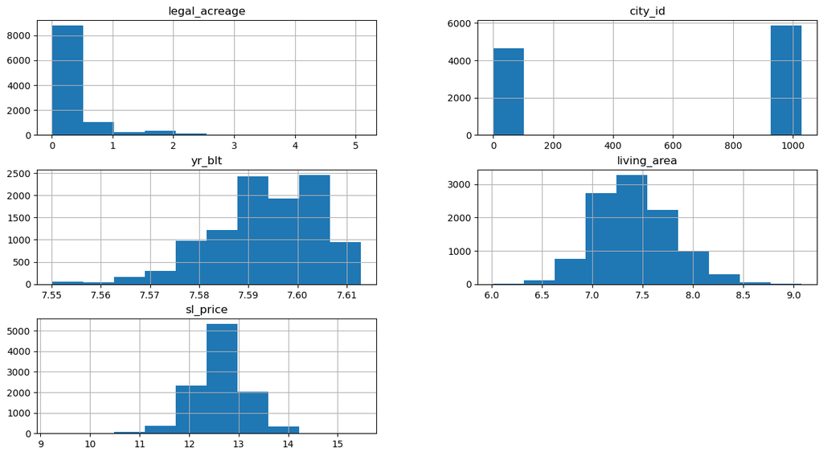

```python
result.hist(figsize =(15,8))
```

```python
result['legal_acreage'] = np.log(result['legal_acreage'] + 1)
result['sl_price'] = np.log(result['sl_price'] + 1)
result['living_area'] = np.log(result['living_area'] + 1)
result['yr_blt'] = np.log(result['yr_blt'] + 1)
```

```
array([[<Axes: title={'center': 'legal_acreage'}>,
        <Axes: title={'center': 'city_id'}>],
       [<Axes: title={'center': 'yr_blt'}>,
        <Axes: title={'center': 'living_area'}>],
       [<Axes: title={'center': 'sl_price'}>, <Axes: >]], dtype=object)
```

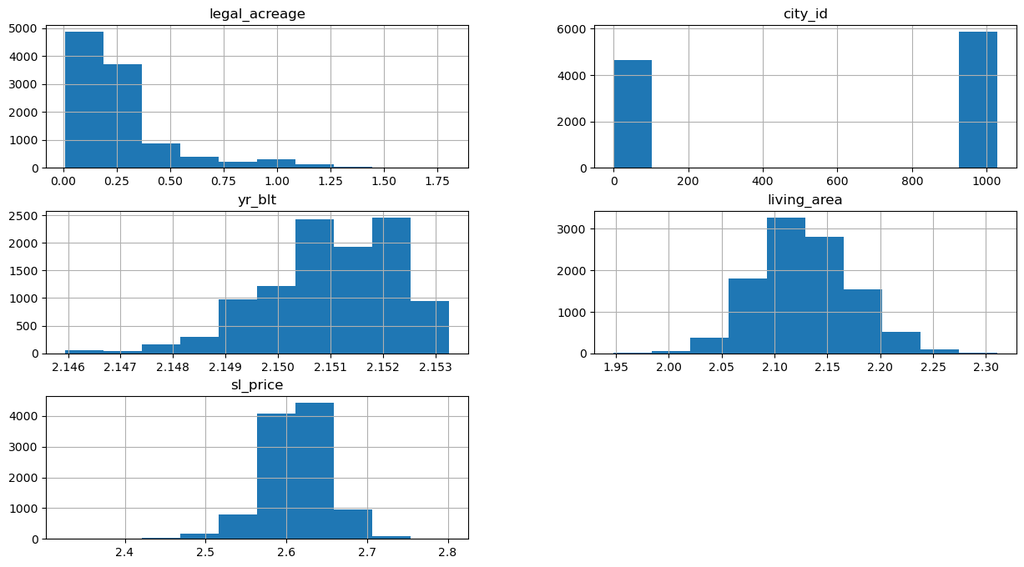

```python
result.hist(figsize =(15,8))
```

```python
market_area_1 = pd.read_csv('MA1_Export_20240719.csv')
market_area_2 = pd.read_csv('MA2_Export_20240719.csv')
market_area_3 = pd.read_csv('MA3_Export_20240719.csv')
data_2 = pd.read_csv("datapull2.csv")
```

```python
market_area_1 = market_area_1[['prop_id', 'Cluster_ID']]
market_area_2 = market_area_2[['prop_id', 'Cluster_ID']]
market_area_3 = market_area_3[['prop_id', 'Cluster_ID']]
```

```python
market_areas = pd.concat([market_area_1, market_area_2, market_area_3])
result = pd.merge(data_2, market_areas, how='left', on='prop_id')
```

```python
result.dropna(inplace=True)
```

```python
result
```

|  | prop_id | legal_acreage | city_id | yr_blt | living_area | land_type_cd | condition_cd | land_total_acres | sl_price | Cluster_ID |
| --- | --- | --- | --- | --- | --- | --- | --- | --- | --- | --- |
| 0 | 1058 | 7.9300 | 0 | 2000 | 2412 | AC | 3 | 7.9300 | 492600 | B1 |
| 1 | 1270 | 2.5700 | 0 | 2005 | 2809 | LT | 4 | 2.5700 | 625300 | B1 |
| 2 | 1307 | 2.0000 | 0 | 2005 | 2508 | AC | 4 | 2.0000 | 535500 | B1 |
| 3 | 1358 | 1.2900 | 1019 | 2005 | 2587 | AC | 4 | 1.2900 | 544500 | B1 |
| 4 | 1416 | 1.0700 | 1019 | 1973 | 2260 | AC | 3 | 1.0700 | 199700 | B1 |
| ... | ... | ... | ... | ... | ... | ... | ... | ... | ... | ... |
| 11124 | 107614 | 0.2342 | 1022 | 2017 | 2028 | LT | 3 | 0.2342 | 402300 | B1 |
| 11126 | 108149 | 0.1983 | 0 | 2021 | 2814 | LT | 4 | 0.1983 | 657700 | B2 |
| 11161 | 502621 | 1.0700 | 0 | 1967 | 1344 | AC | 3 | 1.0700 | 235300 | A1 |
| 11164 | 503179 | 0.2300 | 1018 | 1930 | 1374 | UN | 2 | 0.2300 | 27200 | C4 |
| 11179 | 504928 | 1.9000 | 0 | 1977 | 1534 | AC | 3 | 1.9000 | 408800 | B2 |

10513 rows × 10 columns

```python
result = result.drop(['prop_id'], axis=1)
```

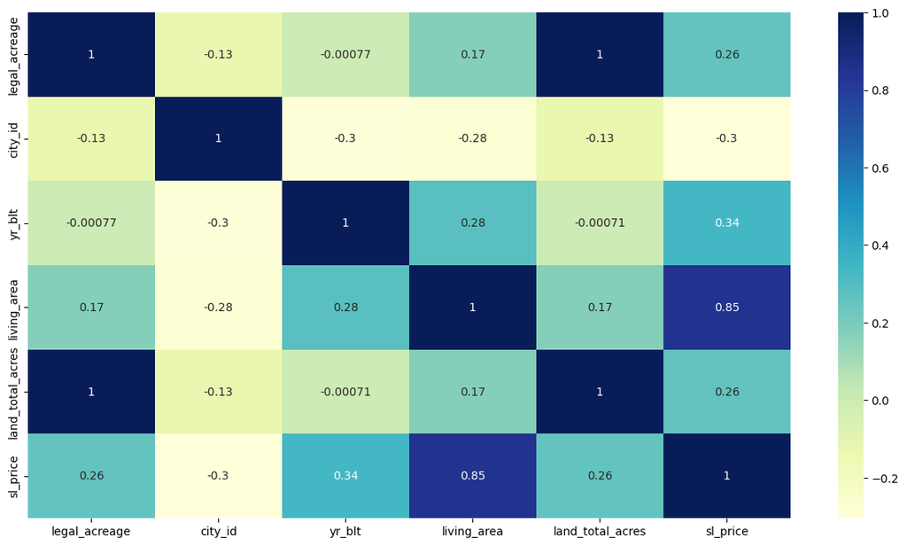

```python
plt.figure(figsize=(15,8))
sns.heatmap(result.corr(numeric_only=True), annot=True, cmap="YlGnBu")
```

```
array([[<Axes: title={'center': 'legal_acreage'}>,
        <Axes: title={'center': 'city_id'}>],
       [<Axes: title={'center': 'yr_blt'}>,
        <Axes: title={'center': 'living_area'}>],
       [<Axes: title={'center': 'land_total_acres'}>,
        <Axes: title={'center': 'sl_price'}>]], dtype=object)
```

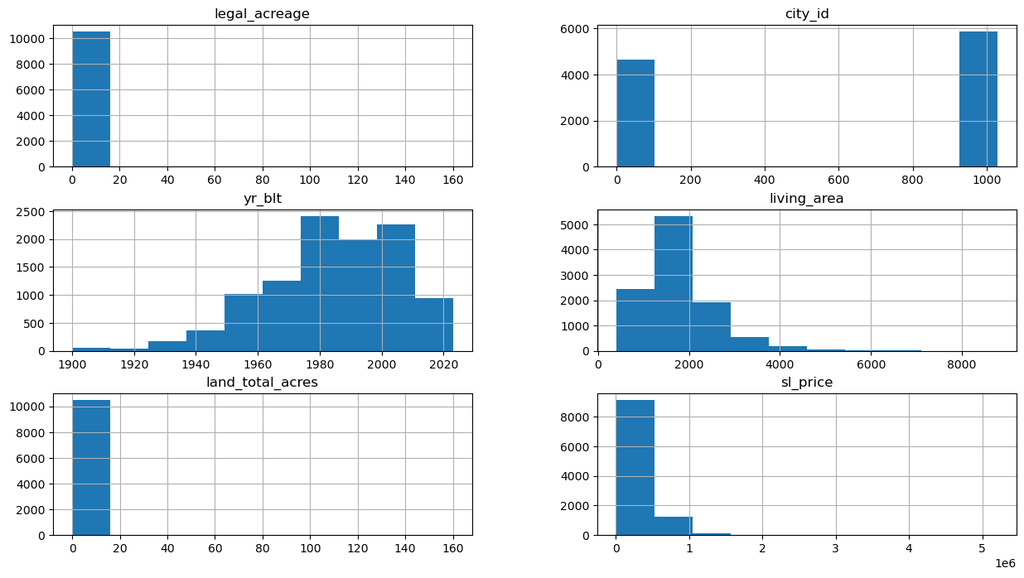

```python
result.hist(figsize =(15,8))
```

```python
result=result.drop(['land_total_acres'], axis=1)
# %
```

```
array([[<Axes: title={'center': 'legal_acreage'}>,
        <Axes: title={'center': 'city_id'}>],
       [<Axes: title={'center': 'yr_blt'}>,
        <Axes: title={'center': 'living_area'}>],
       [<Axes: title={'center': 'sl_price'}>, <Axes: >]], dtype=object)
```

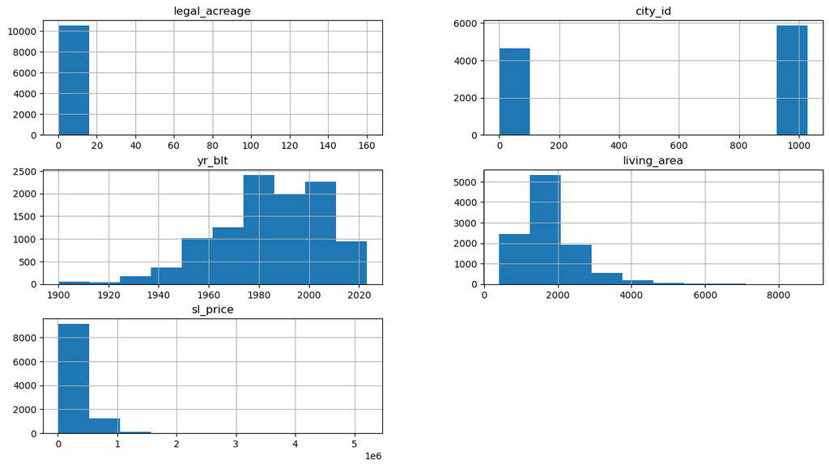

```python
result.hist(figsize =(15,8))
```

```python
result['legal_acreage'] = np.log(result['legal_acreage'] + 1)
result['sl_price'] = np.log(result['sl_price'] + 1)
result['living_area'] = np.log(result['living_area'] + 1)
result['yr_blt'] = np.log(result['yr_blt'] + 1)
```

```
array([[<Axes: title={'center': 'legal_acreage'}>,
        <Axes: title={'center': 'city_id'}>],
       [<Axes: title={'center': 'yr_blt'}>,
        <Axes: title={'center': 'living_area'}>],
       [<Axes: title={'center': 'sl_price'}>, <Axes: >]], dtype=object)
```

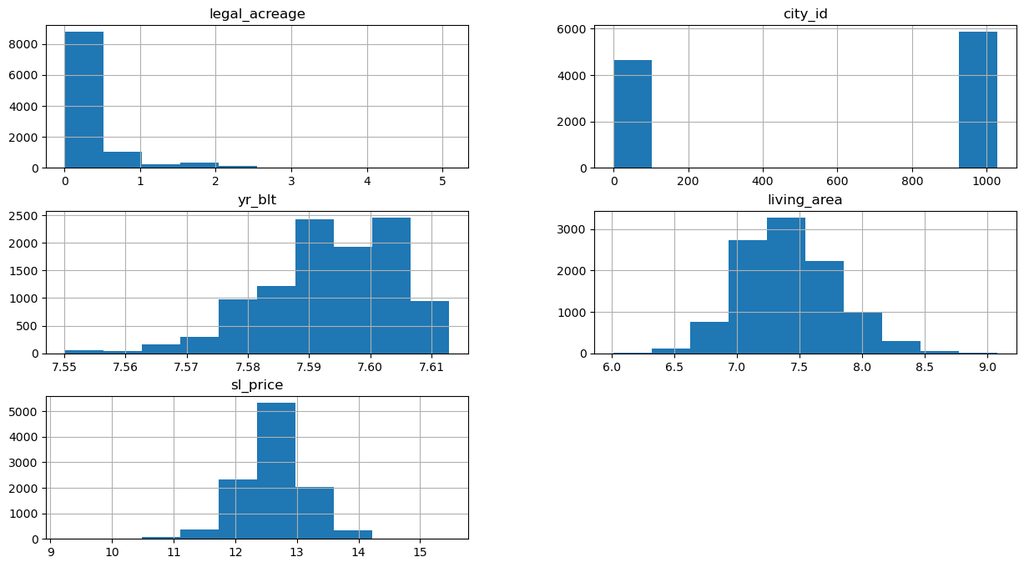

```python
result.hist(figsize =(15,8))
```

```python
print(result.columns)
print(result.dtypes)
```

```
Index(['legal_acreage', 'city_id', 'yr_blt', 'living_area', 'land_type_cd',
       'condition_cd', 'sl_price', 'Cluster_ID'],
      dtype='object')
legal_acreage    float64
city_id            int64
yr_blt           float64
living_area      float64
land_type_cd      object
condition_cd      object
sl_price         float64
Cluster_ID        object
dtype: object
```

```python
result.city_id.value_counts()
result.land_type_cd.value_counts()
result.Cluster_ID.value_counts()
result.condition_cd.value_counts()
```

```
condition_cd
3        7481
4        2455
5         417
2         133
6          24
1           2
X           1
Name: count, dtype: int64
```

```python
result.city_id.value_counts()
```

```
city_id
0       4658
1016    3692
1017     639
1014     576
1019     425
1022     342
1018      69
1015      54
1021      29
1028      22
1020       7
Name: count, dtype: int64
```

```python
result.land_type_cd.value_counts()
```

```
land_type_cd
UN    5223
LT    4365
AC     726
SF     159
FF      40
Name: count, dtype: int64
```

```python
result.Cluster_ID.value_counts()
```

```
Cluster_ID
A2    2886
A1    2628
B1    1287
C4     807
A3     790
C3     684
B2     573
B3     420
C1     242
C2     196
Name: count, dtype: int64
```

```python
market_area_1 = pd.read_csv('MA1_Export_20240719.csv')
market_area_2 = pd.read_csv('MA2_Export_20240719.csv')
market_area_3 = pd.read_csv('MA3_Export_20240719.csv')
data_2 = pd.read_csv("datapull2.csv")
```

```python
market_area_1 = market_area_1[['prop_id', 'Cluster_ID']]
market_area_2 = market_area_2[['prop_id', 'Cluster_ID']]
market_area_3 = market_area_3[['prop_id', 'Cluster_ID']]
```

```python
market_areas = pd.concat([market_area_1, market_area_2, market_area_3])
result = pd.merge(data_2, market_areas, how='left', on='prop_id')
```

```python
print(result.columns)
print(result.dtypes)
```

```
Index(['prop_id', 'legal_acreage', 'city_id', 'yr_blt', 'living_area',
       'land_type_cd', 'condition_cd', 'land_total_acres', 'sl_price',
       'Cluster_ID'],
      dtype='object')
prop_id               int64
legal_acreage       float64
city_id               int64
yr_blt                int64
living_area           int64
land_type_cd         object
condition_cd        float64
land_total_acres    float64
sl_price              int64
Cluster_ID           object
dtype: object
```

```python
result.dropna(inplace=True)
```

```python
result = result.drop(['prop_id'], axis=1)
```

```python
result=result.drop(['land_total_acres'], axis=1)
# %
```

```
array([[<Axes: title={'center': 'legal_acreage'}>,
        <Axes: title={'center': 'city_id'}>],
       [<Axes: title={'center': 'yr_blt'}>,
        <Axes: title={'center': 'living_area'}>],
       [<Axes: title={'center': 'condition_cd'}>,
        <Axes: title={'center': 'sl_price'}>]], dtype=object)
```

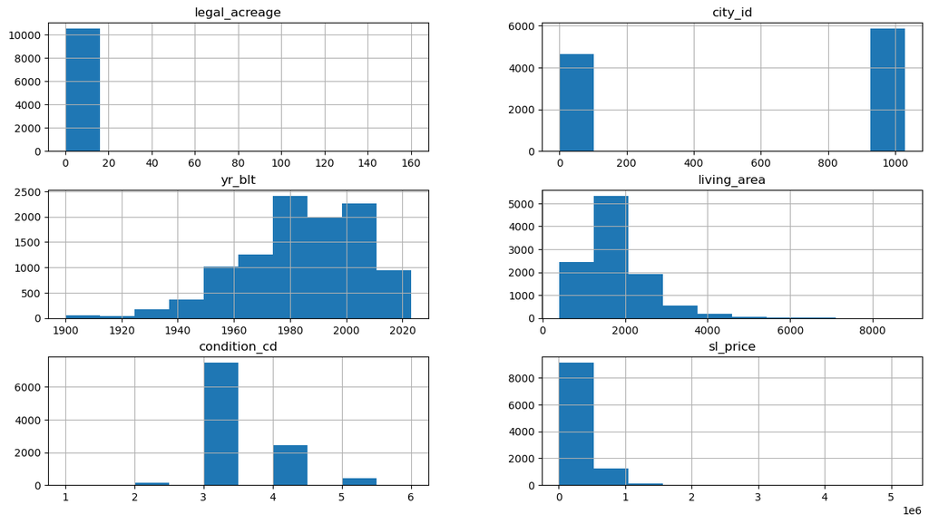

```python
result.hist(figsize =(15,8))
```

```python
result['legal_acreage'] = np.log(result['legal_acreage'] + 1)
result['sl_price'] = np.log(result['sl_price'] + 1)
result['living_area'] = np.log(result['living_area'] + 1)
result['yr_blt'] = np.log(result['yr_blt'] + 1)
```

```
array([[<Axes: title={'center': 'legal_acreage'}>,
        <Axes: title={'center': 'city_id'}>],
       [<Axes: title={'center': 'yr_blt'}>,
        <Axes: title={'center': 'living_area'}>],
       [<Axes: title={'center': 'condition_cd'}>,
        <Axes: title={'center': 'sl_price'}>]], dtype=object)
```

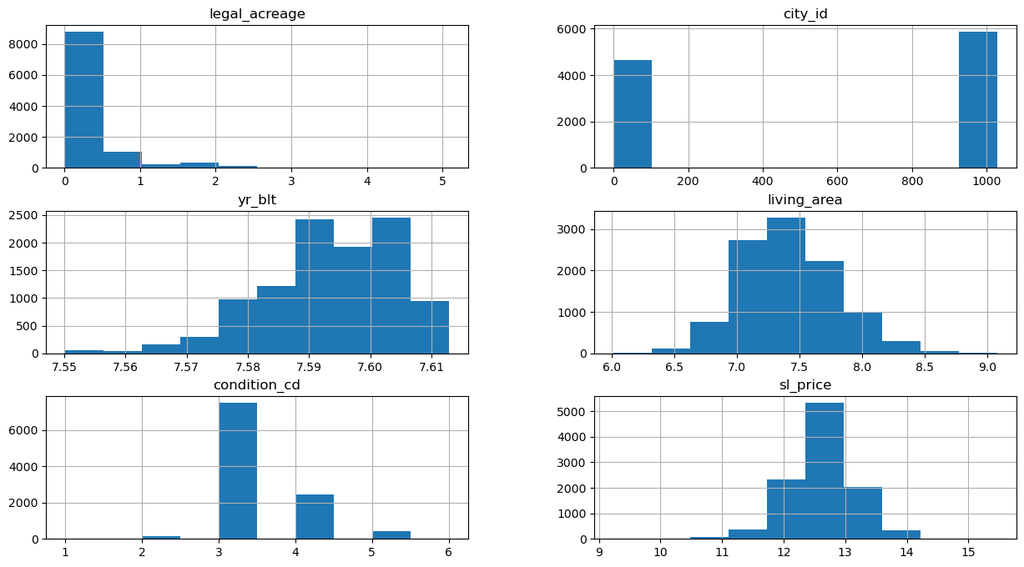

```python
result.hist(figsize =(15,8))
```

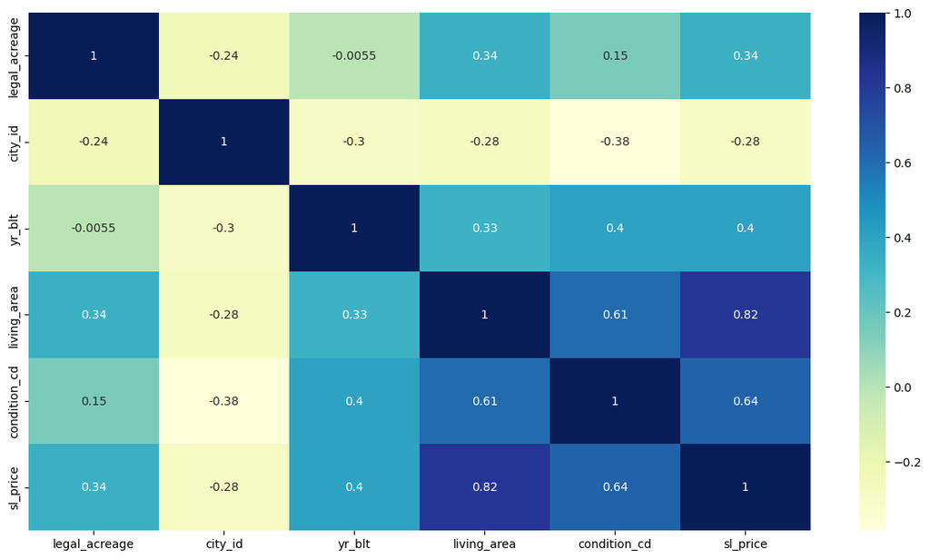

```python
plt.figure(figsize=(15,8))
sns.heatmap(result.corr(numeric_only=True), annot=True, cmap="YlGnBu")
```

```python
result.city_id.value_counts()
```

```
city_id
0       4657
1016    3692
1017     639
1014     576
1019     425
1022     342
1018      69
1015      54
1021      29
1028      22
1020       7
Name: count, dtype: int64
```

```python
result.join(pd.get_dummies(result.city_id))
```

|  | legal_acreage | city_id | yr_blt | living_area | land_type_cd | condition_cd | sl_price | Cluster_ID | 0 | 1014 | 1015 | 1016 | 1017 | 1018 | 1019 | 1020 | 1021 | 1022 | 1028 |
| --- | --- | --- | --- | --- | --- | --- | --- | --- | --- | --- | --- | --- | --- | --- | --- | --- | --- | --- | --- |
| 0 | 2.189416 | 0 | 7.601402 | 7.788626 | AC | 3.0 | 13.107455 | B1 | True | False | False | False | False | False | False | False | False | False | False |
| 1 | 1.272566 | 0 | 7.603898 | 7.940940 | LT | 4.0 | 13.345988 | B1 | True | False | False | False | False | False | False | False | False | False | False |
| 2 | 1.098612 | 0 | 7.603898 | 7.827640 | AC | 4.0 | 13.190958 | B1 | True | False | False | False | False | False | False | False | False | False | False |
| 3 | 0.828552 | 1019 | 7.603898 | 7.858641 | AC | 4.0 | 13.207625 | B1 | False | False | False | False | False | False | True | False | False | False | False |
| 4 | 0.727549 | 1019 | 7.587817 | 7.723562 | AC | 3.0 | 12.204577 | B1 | False | False | False | False | False | False | True | False | False | False | False |
| ... | ... | ... | ... | ... | ... | ... | ... | ... | ... | ... | ... | ... | ... | ... | ... | ... | ... | ... | ... |
| 11123 | 0.210423 | 1022 | 7.609862 | 7.615298 | LT | 3.0 | 12.904956 | B1 | False | False | False | False | False | False | False | False | False | True | False |
| 11125 | 0.180904 | 0 | 7.611842 | 7.942718 | LT | 4.0 | 13.396506 | B2 | True | False | False | False | False | False | False | False | False | False | False |
| 11160 | 0.727549 | 0 | 7.584773 | 7.204149 | AC | 3.0 | 12.368621 | A1 | True | False | False | False | False | False | False | False | False | False | False |
| 11163 | 0.207014 | 1018 | 7.565793 | 7.226209 | UN | 2.0 | 10.211009 | C4 | False | False | False | False | False | True | False | False | False | False | False |
| 11178 | 1.064711 | 0 | 7.589842 | 7.336286 | AC | 3.0 | 12.920984 | B2 | True | False | False | False | False | False | False | False | False | False | False |

10512 rows × 19 columns

```python
result.join(pd.get_dummies(result.land_type_cd))
```

|  | legal_acreage | city_id | yr_blt | living_area | land_type_cd | condition_cd | sl_price | Cluster_ID | AC | FF | LT | SF | UN |
| --- | --- | --- | --- | --- | --- | --- | --- | --- | --- | --- | --- | --- | --- |
| 0 | 2.189416 | 0 | 7.601402 | 7.788626 | AC | 3.0 | 13.107455 | B1 | True | False | False | False | False |
| 1 | 1.272566 | 0 | 7.603898 | 7.940940 | LT | 4.0 | 13.345988 | B1 | False | False | True | False | False |
| 2 | 1.098612 | 0 | 7.603898 | 7.827640 | AC | 4.0 | 13.190958 | B1 | True | False | False | False | False |
| 3 | 0.828552 | 1019 | 7.603898 | 7.858641 | AC | 4.0 | 13.207625 | B1 | True | False | False | False | False |
| 4 | 0.727549 | 1019 | 7.587817 | 7.723562 | AC | 3.0 | 12.204577 | B1 | True | False | False | False | False |
| ... | ... | ... | ... | ... | ... | ... | ... | ... | ... | ... | ... | ... | ... |
| 11123 | 0.210423 | 1022 | 7.609862 | 7.615298 | LT | 3.0 | 12.904956 | B1 | False | False | True | False | False |
| 11125 | 0.180904 | 0 | 7.611842 | 7.942718 | LT | 4.0 | 13.396506 | B2 | False | False | True | False | False |
| 11160 | 0.727549 | 0 | 7.584773 | 7.204149 | AC | 3.0 | 12.368621 | A1 | True | False | False | False | False |
| 11163 | 0.207014 | 1018 | 7.565793 | 7.226209 | UN | 2.0 | 10.211009 | C4 | False | False | False | False | True |
| 11178 | 1.064711 | 0 | 7.589842 | 7.336286 | AC | 3.0 | 12.920984 | B2 | True | False | False | False | False |

10512 rows × 13 columns

```python
result.join(pd.get_dummies(result.Cluster_ID))
```

|  | legal_acreage | city_id | yr_blt | living_area | land_type_cd | condition_cd | sl_price | Cluster_ID | A1 | A2 | A3 | B1 | B2 | B3 | C1 | C2 | C3 | C4 |
| --- | --- | --- | --- | --- | --- | --- | --- | --- | --- | --- | --- | --- | --- | --- | --- | --- | --- | --- |
| 0 | 2.189416 | 0 | 7.601402 | 7.788626 | AC | 3.0 | 13.107455 | B1 | False | False | False | True | False | False | False | False | False | False |
| 1 | 1.272566 | 0 | 7.603898 | 7.940940 | LT | 4.0 | 13.345988 | B1 | False | False | False | True | False | False | False | False | False | False |
| 2 | 1.098612 | 0 | 7.603898 | 7.827640 | AC | 4.0 | 13.190958 | B1 | False | False | False | True | False | False | False | False | False | False |
| 3 | 0.828552 | 1019 | 7.603898 | 7.858641 | AC | 4.0 | 13.207625 | B1 | False | False | False | True | False | False | False | False | False | False |
| 4 | 0.727549 | 1019 | 7.587817 | 7.723562 | AC | 3.0 | 12.204577 | B1 | False | False | False | True | False | False | False | False | False | False |
| ... | ... | ... | ... | ... | ... | ... | ... | ... | ... | ... | ... | ... | ... | ... | ... | ... | ... | ... |
| 11123 | 0.210423 | 1022 | 7.609862 | 7.615298 | LT | 3.0 | 12.904956 | B1 | False | False | False | True | False | False | False | False | False | False |
| 11125 | 0.180904 | 0 | 7.611842 | 7.942718 | LT | 4.0 | 13.396506 | B2 | False | False | False | False | True | False | False | False | False | False |
| 11160 | 0.727549 | 0 | 7.584773 | 7.204149 | AC | 3.0 | 12.368621 | A1 | True | False | False | False | False | False | False | False | False | False |
| 11163 | 0.207014 | 1018 | 7.565793 | 7.226209 | UN | 2.0 | 10.211009 | C4 | False | False | False | False | False | False | False | False | False | True |
| 11178 | 1.064711 | 0 | 7.589842 | 7.336286 | AC | 3.0 | 12.920984 | B2 | False | False | False | False | True | False | False | False | False | False |

10512 rows × 18 columns

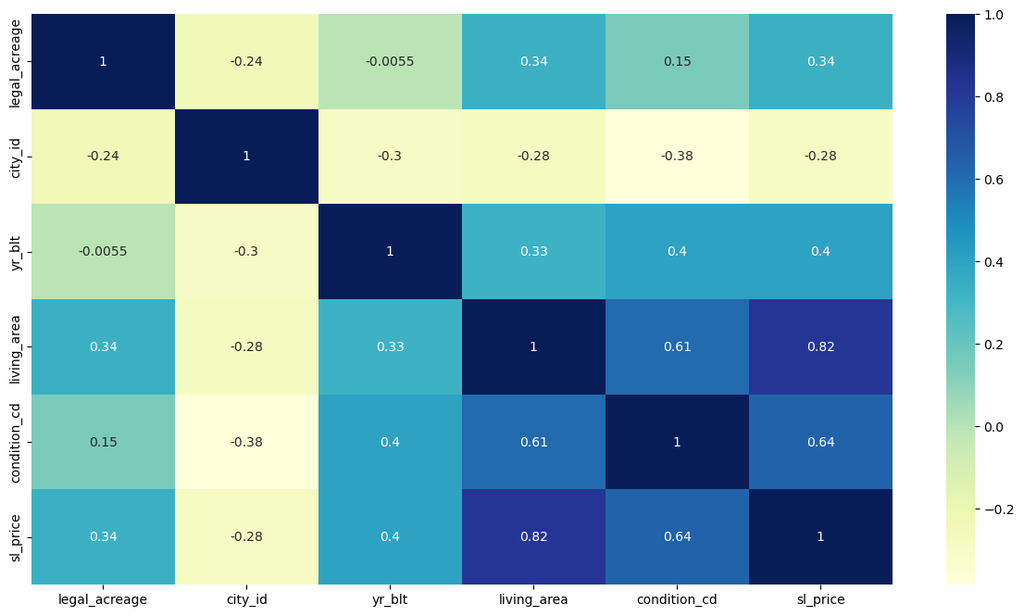

```python
plt.figure(figsize=(15,8))
sns.heatmap(result.corr(numeric_only=True), annot=True, cmap="YlGnBu")
```

```python
result=result.drop(['city_id'], axis=1)
```

```python
result=result.drop(['land_type_cd'], axis=1)
```

```python
result=result.drop(['Cluster_ID'], axis=1)
```

```python
result
```

|  | legal_acreage | yr_blt | living_area | condition_cd | sl_price |
| --- | --- | --- | --- | --- | --- |
| 0 | 2.189416 | 7.601402 | 7.788626 | 3.0 | 13.107455 |
| 1 | 1.272566 | 7.603898 | 7.940940 | 4.0 | 13.345988 |
| 2 | 1.098612 | 7.603898 | 7.827640 | 4.0 | 13.190958 |
| 3 | 0.828552 | 7.603898 | 7.858641 | 4.0 | 13.207625 |
| 4 | 0.727549 | 7.587817 | 7.723562 | 3.0 | 12.204577 |
| ... | ... | ... | ... | ... | ... |
| 11123 | 0.210423 | 7.609862 | 7.615298 | 3.0 | 12.904956 |
| 11125 | 0.180904 | 7.611842 | 7.942718 | 4.0 | 13.396506 |
| 11160 | 0.727549 | 7.584773 | 7.204149 | 3.0 | 12.368621 |
| 11163 | 0.207014 | 7.565793 | 7.226209 | 2.0 | 10.211009 |
| 11178 | 1.064711 | 7.589842 | 7.336286 | 3.0 | 12.920984 |

10512 rows × 5 columns

```python
market_area_1 = pd.read_csv('MA1_Export_20240719.csv')
market_area_2 = pd.read_csv('MA2_Export_20240719.csv')
market_area_3 = pd.read_csv('MA3_Export_20240719.csv')
data_2 = pd.read_csv("datapull2.csv")
```

```python
market_area_1 = market_area_1[['prop_id', 'Cluster_ID']]
market_area_2 = market_area_2[['prop_id', 'Cluster_ID']]
market_area_3 = market_area_3[['prop_id', 'Cluster_ID']]
```

```python
market_areas = pd.concat([market_area_1, market_area_2, market_area_3])
result = pd.merge(data_2, market_areas, how='left', on='prop_id')
```

```python
result.dropna(inplace=True)
```

```python
result = result.drop(['prop_id'], axis=1)
```

```python
result=result.drop(['land_total_acres'], axis=1)
# %
```

```python
result
```

|  | legal_acreage | city_id | yr_blt | living_area | land_type_cd | condition_cd | sl_price | Cluster_ID |
| --- | --- | --- | --- | --- | --- | --- | --- | --- |
| 0 | 7.9300 | 0 | 2000 | 2412 | AC | 3.0 | 492600 | B1 |
| 1 | 2.5700 | 0 | 2005 | 2809 | LT | 4.0 | 625300 | B1 |
| 2 | 2.0000 | 0 | 2005 | 2508 | AC | 4.0 | 535500 | B1 |
| 3 | 1.2900 | 1019 | 2005 | 2587 | AC | 4.0 | 544500 | B1 |
| 4 | 1.0700 | 1019 | 1973 | 2260 | AC | 3.0 | 199700 | B1 |
| ... | ... | ... | ... | ... | ... | ... | ... | ... |
| 11123 | 0.2342 | 1022 | 2017 | 2028 | LT | 3.0 | 402300 | B1 |
| 11125 | 0.1983 | 0 | 2021 | 2814 | LT | 4.0 | 657700 | B2 |
| 11160 | 1.0700 | 0 | 1967 | 1344 | AC | 3.0 | 235300 | A1 |
| 11163 | 0.2300 | 1018 | 1930 | 1374 | UN | 2.0 | 27200 | C4 |
| 11178 | 1.9000 | 0 | 1977 | 1534 | AC | 3.0 | 408800 | B2 |

10512 rows × 8 columns

```python
result['legal_acreage'] = np.log(result['legal_acreage'] + 1)
result['sl_price'] = np.log(result['sl_price'] + 1)
result['living_area'] = np.log(result['living_area'] + 1)
result['yr_blt'] = np.log(result['yr_blt'] + 1)
```

```
array([[<Axes: title={'center': 'legal_acreage'}>,
        <Axes: title={'center': 'city_id'}>],
       [<Axes: title={'center': 'yr_blt'}>,
        <Axes: title={'center': 'living_area'}>],
       [<Axes: title={'center': 'condition_cd'}>,
        <Axes: title={'center': 'sl_price'}>]], dtype=object)
```

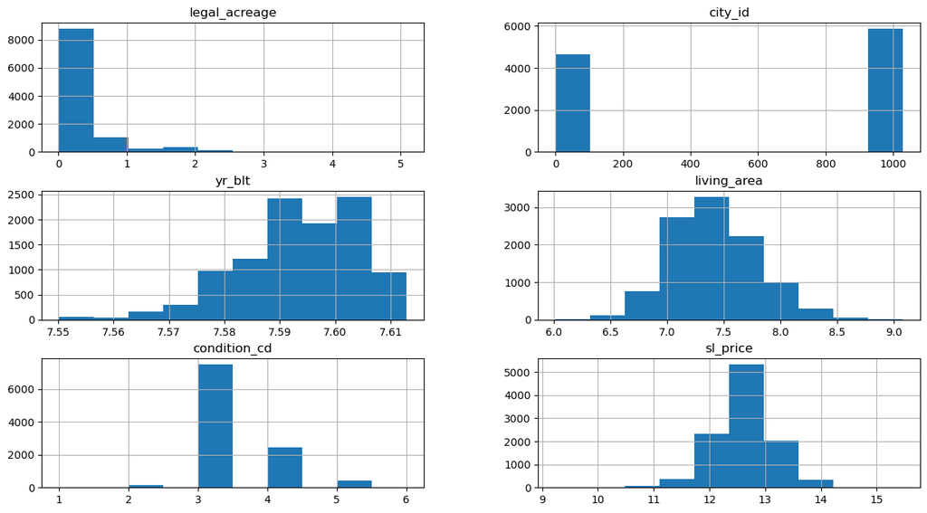

```python
result.hist(figsize =(15,8))
```

```python
result = result.join(pd.get_dummies(result.city_id)).drop(['city_id'], axis=1)
```

```python
result
```

|  | legal_acreage | yr_blt | living_area | land_type_cd | condition_cd | sl_price | Cluster_ID | 0 | 1014 | 1015 | 1016 | 1017 | 1018 | 1019 | 1020 | 1021 | 1022 | 1028 |
| --- | --- | --- | --- | --- | --- | --- | --- | --- | --- | --- | --- | --- | --- | --- | --- | --- | --- | --- |
| 0 | 2.189416 | 7.601402 | 7.788626 | AC | 3.0 | 13.107455 | B1 | True | False | False | False | False | False | False | False | False | False | False |
| 1 | 1.272566 | 7.603898 | 7.940940 | LT | 4.0 | 13.345988 | B1 | True | False | False | False | False | False | False | False | False | False | False |
| 2 | 1.098612 | 7.603898 | 7.827640 | AC | 4.0 | 13.190958 | B1 | True | False | False | False | False | False | False | False | False | False | False |
| 3 | 0.828552 | 7.603898 | 7.858641 | AC | 4.0 | 13.207625 | B1 | False | False | False | False | False | False | True | False | False | False | False |
| 4 | 0.727549 | 7.587817 | 7.723562 | AC | 3.0 | 12.204577 | B1 | False | False | False | False | False | False | True | False | False | False | False |
| ... | ... | ... | ... | ... | ... | ... | ... | ... | ... | ... | ... | ... | ... | ... | ... | ... | ... | ... |
| 11123 | 0.210423 | 7.609862 | 7.615298 | LT | 3.0 | 12.904956 | B1 | False | False | False | False | False | False | False | False | False | True | False |
| 11125 | 0.180904 | 7.611842 | 7.942718 | LT | 4.0 | 13.396506 | B2 | True | False | False | False | False | False | False | False | False | False | False |
| 11160 | 0.727549 | 7.584773 | 7.204149 | AC | 3.0 | 12.368621 | A1 | True | False | False | False | False | False | False | False | False | False | False |
| 11163 | 0.207014 | 7.565793 | 7.226209 | UN | 2.0 | 10.211009 | C4 | False | False | False | False | False | True | False | False | False | False | False |
| 11178 | 1.064711 | 7.589842 | 7.336286 | AC | 3.0 | 12.920984 | B2 | True | False | False | False | False | False | False | False | False | False | False |

10512 rows × 18 columns

```python
result = result.join(pd.get_dummies(result.land_type_cd)).drop(['land_type_cd'], axis=1)
```

```python
result.join(pd.get_dummies(result.Cluster_ID)).drop(['Cluster_ID'], axis=1)
```

|  | legal_acreage | yr_blt | living_area | condition_cd | sl_price | 0 | 1014 | 1015 | 1016 | 1017 | ... | A1 | A2 | A3 | B1 | B2 | B3 | C1 | C2 | C3 | C4 |
| --- | --- | --- | --- | --- | --- | --- | --- | --- | --- | --- | --- | --- | --- | --- | --- | --- | --- | --- | --- | --- | --- |
| 0 | 2.189416 | 7.601402 | 7.788626 | 3.0 | 13.107455 | True | False | False | False | False | ... | False | False | False | True | False | False | False | False | False | False |
| 1 | 1.272566 | 7.603898 | 7.940940 | 4.0 | 13.345988 | True | False | False | False | False | ... | False | False | False | True | False | False | False | False | False | False |
| 2 | 1.098612 | 7.603898 | 7.827640 | 4.0 | 13.190958 | True | False | False | False | False | ... | False | False | False | True | False | False | False | False | False | False |
| 3 | 0.828552 | 7.603898 | 7.858641 | 4.0 | 13.207625 | False | False | False | False | False | ... | False | False | False | True | False | False | False | False | False | False |
| 4 | 0.727549 | 7.587817 | 7.723562 | 3.0 | 12.204577 | False | False | False | False | False | ... | False | False | False | True | False | False | False | False | False | False |
| ... | ... | ... | ... | ... | ... | ... | ... | ... | ... | ... | ... | ... | ... | ... | ... | ... | ... | ... | ... | ... | ... |
| 11123 | 0.210423 | 7.609862 | 7.615298 | 3.0 | 12.904956 | False | False | False | False | False | ... | False | False | False | True | False | False | False | False | False | False |
| 11125 | 0.180904 | 7.611842 | 7.942718 | 4.0 | 13.396506 | True | False | False | False | False | ... | False | False | False | False | True | False | False | False | False | False |
| 11160 | 0.727549 | 7.584773 | 7.204149 | 3.0 | 12.368621 | True | False | False | False | False | ... | True | False | False | False | False | False | False | False | False | False |
| 11163 | 0.207014 | 7.565793 | 7.226209 | 2.0 | 10.211009 | False | False | False | False | False | ... | False | False | False | False | False | False | False | False | False | True |
| 11178 | 1.064711 | 7.589842 | 7.336286 | 3.0 | 12.920984 | True | False | False | False | False | ... | False | False | False | False | True | False | False | False | False | False |

10512 rows × 31 columns

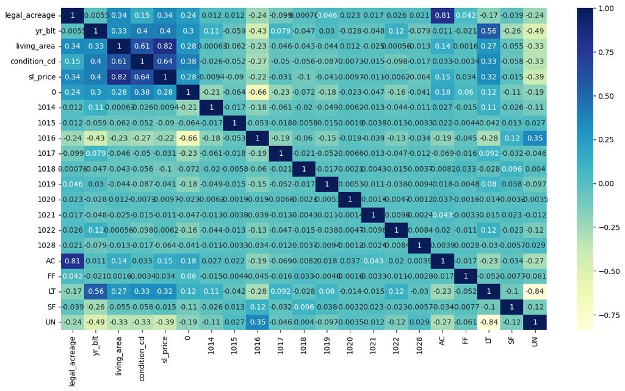

```python
plt.figure(figsize=(15,8))
sns.heatmap(result.corr(numeric_only=True), annot=True, cmap="YlGnBu")
```

Weak correlation for individual city ID's but since 0 had some correaltion, presence in A city seems more important than which city a prop is in. Running out of time today so Im going to run with this data for now but city_id and land_type_cd might be kind of useless.

```python
from sklearn.model_selection import train_test_split

X = result.drop(['sl_price'], axis=1)
y = result['sl_price']
```

```python
X_train, X_test, y_train, y_test = train_test_split(X, y, test_size=0.2)
```

```python
train_data = X_train.join(y_train)
```